# Pipeline estándar: otros datos genómicos

Mª Araceli Hernández Betancor

24/6/2020

## Introducción

El análisis bioinformático y estadístico de datos de mRNA es un campo en desarrollo, con un avance notable en los últimos años. Encontrar *datasets* para entrenamiento para principiantes no es sencillo. Probablemente uno de los campos en los que más se ha investigado es la patología oncológica. Por ese motivo, para el desarrollo de este *pipeline* se ha intentado reproducir el *workflow* para Bioconductor planteado por Tiago C. Silva *et al.*

En el artículo se hace mención a tres grandes repositorios **TCGA**, **ENCODE** y **Roadmap**.

- **TCGA**: es el acrónimo de *The Cancer Genome Atlas*, un ambicioso proyecto promovido a partir del año 2005 por el *National Cancer Institute* y *National Human Genome Research Institute* en la lucha contra el cáncer. Se trata de un catálogo de alteraciones biológicas relacionadas con el desarrollo de procesos oncológicos mediante la aplicación de la secuenciación genómica y el análisis bioinformático de datos. Busca el diagnóstico y tratamiento precoz, así como la prevención de procesos oncológicos a través de la comprensión de las modificaciones genéticas implicadas en su desarrollo. Dispone de información de más de 10.000 tumores relacionados con distinto tipo de procesos neoplásicos de distinta localización.
- **ENCODE**: es la *Encyclopedia of DNA Elements* para el seguimiento del *Proyecto Genoma Humano*. ENCODE busca identificar los elementos funcionales del genoma gumano. Promovido por el NHGRI *(National Human Genome Research Institute)* en 2003, actualmente implica a grupos de investigación de todo el mundo, con una amplia base de datos de acceso público.
- **NIH Roadmap Epigenomics Project**: este proyecto pretende generar una base de datos de epigenomas humanos de referencia de individuos sanos a través de distintas líneas celulares, células y tejidos primarios. Estos datos son accesibles mediante el *Human Epigenome Atlas*. Se analiza el epigenoma desde diferentes perspectivas, asi como su expresión génica: Chip-Seq en el análisis de modificación de histonas, metilación de DNA, DNA-seq y accesibilidad de cromatina, expresión génica (RNA-seq como mRNA, expresión de arrays), y expresión de small-RNA (smRNA-Seq). En este último punto entraría el análisis de micro o mi-RNA.

A continuación utilizando el programa Bioconductor empleado durante el Máster para el análisis de datos ómicos, se intenta reproducir el *workflow* desarrollado en el artículo (https://f1000research.com/articles/5-1542/v2). Este artículo sigue un esquema similar al utilizado en las prácticas de la asignatura de Análisis de Datos Ómicos, desde la descarga del *dataset*, procesamiento y análisis para responder a la pregunta biológica inicial, y discutir sobre la posible significación biológica de los resultados obtenidos.

Antes de iniciar la desacarga del conjunto de datos se instalaron los paquetes necesarios del proyecto Bioconductor que se cargan al inicio del fichero .Rmd.

## Descarga de *dataset*

Se descarga el conjunto de datos de *TCGA* utilizando el paquete de Bioconductor “TCGAbiolinks”. Como se realiza en el estudio planteado se utilizan las funciones *GDCquery()*, *GDCdownload()* y *GDCprepare()* para la búsqueda, descarga y preparación de los datos, como su nombre indica. Con la primera función se busca mediante la GDC API la información de un proyecto concreto, obteniéndose un objeto con una tabla resumen, información que se descarga con la segunda función y se guarda en un directorio. Finalmente con la tercera función se preparan los datos para su uso.

```r
# Datos alineados a hg19
library(TCGAbiolinks)
query.met.gbm <- GDCquery(project = "TCGA-GBM",
                          legacy = TRUE,
                          data.category = "DNA methylation",
                          platform = "Illumina Human Methylation 450",
                          barcode = c("TCGA-76-4926-01B-01D-1481-05", "TCGA-28-5211-01C-11D-1844-05"))

GDCdownload(query.met.gbm)

met.gbm.450 <- GDCprepare(query = query.met.gbm,
                          save = TRUE,
                          save.filename = "gbmDNAmet450k.rda",
                          summarizedExperiment = TRUE)

query.met.lgg <- GDCquery(project = "TCGA-LGG",
                          legacy = TRUE,
                          data.category = "DNA methylation",
                          platform = "Illumina Human Methylation 450",
                          barcode = c("TCGA-HT-7879-01A-11D-2399-05", "TCGA-HT-8113-01A-11D-2399-05"))

GDCdownload(query.met.lgg)

met.lgg.450 <- GDCprepare(query = query.met.lgg,
                          save = TRUE,
                          save.filename = "lggDNAmet450k.rda",
                          summarizedExperiment = TRUE)

met.gbm.lgg <- SummarizedExperiment::cbind(met.lgg.450, met.gbm.450)

query.exp.lgg <- GDCquery(project = "TCGA-LGG",
                          legacy = TRUE,
                          data.category = "Gene expression",
                          data.type = "Gene expression quantification",
                          platform = "Illumina HiSeq",
                          file.type = "results",
                          sample.type = "Primary solid Tumor")

GDCdownload(query.exp.lgg)

exp.lgg <- GDCprepare(query = query.exp.lgg, save = TRUE, save.filename = "lggExp.rda")

query.exp.gbm <- GDCquery(project = "TCGA-GBM",
                          legacy = TRUE,
                          data.category = "Gene expression",
                          data.type = "Gene expression quantification",
                          platform = "Illumina HiSeq",
                          file.type = "results",
                          sample.type = "Primary solid Tumor")

GDCdownload(query.exp.gbm)

exp.gbm <- GDCprepare(query = query.exp.gbm,
                      save = TRUE,
                      save.filename = "gbmExp.rda")

exp.gbm.lgg <- SummarizedExperiment::cbind(exp.lgg, exp.gbm)
```

```r
# Copy number variation, alineado a hg38
query <- GDCquery(project = "TCGA-ACC",
                  data.category = "Copy Number Variation",
                  data.type = "Copy Number Segment",
                  barcode = c( "TCGA-OR-A5KU-01A-11D-A29H-01", "TCGA-OR-A5JK-01A-11D-A29H-01"))

GDCdownload(query)

data <- GDCprepare(query)

query <- GDCquery("TCGA-ACC",
                  "Copy Number Variation",
                  data.type = "Masked Copy Number Segment",
                  sample.type = c("Primary solid Tumor"))

getResults(query)$cases # barcodes

GDCdownload(query)

data <- GDCprepare(query)
```

## Exploración y análisis de los datos

A continuación se procede a la exploración de los datos (paciente, *batch*, tipo de muestra, etc.).

```r
library(SummarizedExperiment)

# Se carga objeto con paquete TCGAWorkflowData

data(GBMIllumina_HiSeq)

# Matrix de expresión
data <- assay(gbm.exp)
datatable(data[1:10,],
          options = list(scrollX = TRUE, keys = TRUE, pageLength = 5),
          rownames = TRUE)
```

|  | TCGA-28-1753-01A-01R-1850-01 | TCGA-06-0749-01A-01R-1849-01 | TCGA-28-1747-01C-01R-1850-01 | TCGA-27-1834-01A-01R-1850-01 | TCGA-28-5220-01A-01R-1850-01 | TCGA-06-0132-01A-02R-1849-01 | TCGA-19-2620-01A-01R-1850-01 | TCGA-12-0619-01A-01R-1849-01 | TCGA-15-1444-01A-02R-1850-01 | TCGA-06-5416-01A-01R-1849-01 | TCGA-28-5209-01A-01R-1850-01 | TCGA-12-5295-01A-01R-1849-01 | TCGA-06-0686-01A-01R-1849-01 | TCGA-12-3653-01A-01R-1849-01 | TCGA-32-2634-01A-01R-1850-01 | TCGA-26-5139-01A-01R-1850-01 | TCGA-06-0750-01A-01R-1849-01 | TCGA-76-4927-01A-01R-1850-01 | TCGA-28-5218-01A-01R-1850-01 | TCGA-06-5856-01A-01R-1849-01 |
| --- | --- | --- | --- | --- | --- | --- | --- | --- | --- | --- | --- | --- | --- | --- | --- | --- | --- | --- | --- | --- |
| A1BG\|1 | 176.6 | 603.41 | 173.63 | 419.63 | 217.89 | 215.09 | 97.52 | 408.74 | 279.55 | 376.27 | 42.71 | 1541.97 | 241.92 | 280.76 | 656.63 | 220.98 | 521.94 | 202.57 | 59.95 | 104.42 |
| A2M\|2 | 23071.89 | 23619.77 | 41407.9 | 32596.3 | 15286.62 | 51230.52 | 24691.6 | 42497.91 | 54318.73 | 11737.48 | 29742.9 | 34799.76 | 17433.93 | 8756.98 | 50473.82 | 30522.79 | 37311.51 | 39475.68 | 71954.66 | 51546.82 |
| NAT1\|9 | 51 | 104 | 156 | 148 | 79 | 150 | 71 | 177 | 85 | 141 | 56 | 59 | 36 | 28 | 342 | 116 | 131 | 75 | 264 | 89 |
| NAT2\|10 | 11 | 17 | 23 | 26 | 22 | 10 | 14 | 14 | 189 | 3 | 7 | 9 | 7 | 0 | 35 | 4 | 14 | 8 | 4 | 41 |
| SERPINA3\|12 | 8742 | 137493 | 127501 | 23065 | 4444 | 73236 | 39299 | 200669 | 48067 | 13030 | 23816 | 30816 | 32984 | 7269 | 25012 | 124974 | 28509 | 53558 | 7880 | 28575 |
| SERPINA3\|12 | 8742 | 137493 | 127501 | 23065 | 4444 | 73236 | 39299 | 200669 | 48067 | 13030 | 23816 | 30816 | 32984 | 7269 | 25012 | 124974 | 28509 | 53558 | 7880 | 28575 |
| AADAC\|13 | 0 | 0 | 0 | 0 | 0 | 1 | 0 | 1 | 0 | 3 | 0 | 1 | 0 | 0 | 1 | 0 | 1 | 1 | 3 | 1 |
| AAMP\|14 | 1773 | 5663 | 5078 | 4344 | 5619 | 3674 | 2422 | 4818 | 4215 | 2815 | 4560 | 4755 | 1940 | 3967 | 5593 | 4290 | 4818 | 2991 | 4371 | 3907 |
| AANAT\|15 | 3 | 17 | 12 | 8 | 11 | 13 | 8 | 22 | 5 | 4 | 2 | 2 | 5 | 2 | 4 | 7 | 9 | 6 | 2 | 6 |
| AARS\|16 | 2526 | 6663 | 9721 | 4443 | 5934 | 5681 | 5947 | 6345 | 12674 | 5673 | 12495 | 3926 | 2900 | 5419 | 9811 | 8134 | 7639 | 4696 | 4564 | 9417 |

```r
# Información de genes
genes.info <- rowRanges(gbm.exp)
genes.info
```

```
## GRanges object with 21022 ranges and 4 metadata columns:
##                          seqnames              ranges strand |      gene_id
##                             <Rle>           <IRanges>  <Rle> |  <character>
##                   A1BG|1    chr19   58856544-58864865      - |         A1BG
##                    A2M|2    chr12     9220260-9268825      - |          A2M
##                   NAT1|9     chr8   18027986-18081198      + |         NAT1
##                  NAT2|10     chr8   18248755-18258728      + |         NAT2
##              SERPINA3|12    chr14   95058395-95090983      + | RP11-986E7.7
##                      ...      ...                 ...    ... .          ...
##     NCRNA00182|100302692     chrX   73183790-73513409      - |          FTX
##   TMED7-TICAM2|100302736     chr5 114914339-114961858      - | TMED7-TICAM2
##   TMED7-TICAM2|100302736     chr5 114949205-114968689      - |        TMED7
##   TMED7-TICAM2|100302736     chr5 114914339-114961876      - |       TICAM2
##   LOC100303728|100303728     chrX 118599997-118603061      - |  SLC25A5-AS1
##                          entrezgene ensembl_gene_id
##                           <numeric>     <character>
##                   A1BG|1          1 ENSG00000121410
##                    A2M|2          2 ENSG00000175899
##                   NAT1|9          9 ENSG00000171428
##                  NAT2|10         10 ENSG00000156006
##              SERPINA3|12         12 ENSG00000273259
##                      ...        ...             ...
##     NCRNA00182|100302692  100302692 ENSG00000230590
##   TMED7-TICAM2|100302736  100302736 ENSG00000251201
##   TMED7-TICAM2|100302736  100302736 ENSG00000134970
##   TMED7-TICAM2|100302736  100302736 ENSG00000243414
##   LOC100303728|100303728  100303728 ENSG00000224281
##                                                                    transcript_id.transcript_id_TCGA-28-1753-01A-01R-1850-01
##                                                                                                                 <character>
##                   A1BG|1                                                                              uc002qsd.3,uc002qsf.1
##                    A2M|2                                                                   uc001qvj.1,uc001qvk.1,uc009zgk.1
##                   NAT1|9 uc003wyq.2,uc003wyr.2,uc003wys.2,uc003wyt.2,uc003wyu.2,uc003wyv.2,uc010ltc.2,uc010ltd.2,uc011kyl.1
##                  NAT2|10                                                                                         uc003wyw.1
##              SERPINA3|12                       uc001ydo.3,uc001ydp.2,uc001ydq.2,uc001ydr.2,uc001yds.2,uc010avf.1,uc010avg.2
##                      ...                                                                                                ...
##     NCRNA00182|100302692                                                                              uc004ebr.1,uc010nlq.1
##   TMED7-TICAM2|100302736                                                                              uc003krd.2,uc003kre.2
##   TMED7-TICAM2|100302736                                                                              uc003krd.2,uc003kre.2
##   TMED7-TICAM2|100302736                                                                              uc003krd.2,uc003kre.2
##   LOC100303728|100303728                                                                              uc004ere.1,uc004erg.1
##   -------
##   seqinfo: 24 sequences from an unspecified genome; no seqlengths
```

```r
# Información de muestras
sample.info <- colData(gbm.exp)
datatable(as.data.frame(sample.info),
          options = list(scrollX = TRUE, keys = TRUE, pageLength = 5),
          rownames = FALSE)
```

| patient | barcode | sample | shortLetterCode | definition | classification_of_tumor | last_known_disease_status | updated_datetime.x | primary_diagnosis | tumor_stage | age_at_diagnosis | vital_status | morphology | days_to_death | days_to_last_known_disease_status | days_to_last_follow_up | state.x | days_to_recurrence | diagnosis_id | tumor_grade | treatments | tissue_or_organ_of_origin | days_to_birth | progression_or_recurrence | prior_malignancy | site_of_resection_or_biopsy | created_datetime.x | cigarettes_per_day | weight | updated_datetime.y | … |
| --- | --- | --- | --- | --- | --- | --- | --- | --- | --- | --- | --- | --- | --- | --- | --- | --- | --- | --- | --- | --- | --- | --- | --- | --- | --- | --- | --- | --- | --- | --- |
| TCGA-28-1753 | TCGA-28-1753-01A-01R-1850-01 | TCGA-28-1753-01A | TP | Primary solid Tumor | not reported | not reported | 2016-09-02T19:11:19.658754-05:00 | c71.9 | not reported | 19366 | alive | 9440/3 |  |  | 37 |  |  | a0282570-3e64-5c3a-b073-9e1c169f33fc | not reported | {'days_to_treatment': [None], 'updated_datetime': ['2016-09-02T19:11:19.658754-05:00'], 'created_datetime': [None], 'submitter_id': ['TCGA-28-1753_treatment'], 'treatment_id': ['cf6c77d9-fad3-5694-ac4… | c71.9 | -19366 | not reported | not reported | c71.9 |  |  |  | 2016-09-02T19:11:19.658754-05:00 | … |
| TCGA-06-0749 | TCGA-06-0749-01A-01R-1849-01 | TCGA-06-0749-01A | TP | Primary solid Tumor | not reported | not reported | 2016-09-02T19:01:55.836912-05:00 | c71.9 | not reported | 18571 | dead | 9440/3 | 82 |  | 66 |  |  | 8af027e1-3ad6-5221-b295-95c87f1cd184 | not reported | {'days_to_treatment': [None], 'updated_datetime': ['2016-09-02T19:01:55.836912-05:00'], 'created_datetime': [None], 'submitter_id': ['TCGA-06-0749_treatment'], 'treatment_id': ['a8b25625-9be9-544b-aec… | c71.9 | -18571 | not reported | not reported | c71.9 |  |  |  | 2016-09-02T19:01:55.836912-05:00 | … |
| TCGA-28-1747 | TCGA-28-1747-01C-01R-1850-01 | TCGA-28-1747-01C | TP | Primary solid Tumor | not reported | not reported | 2016-09-02T19:11:33.850859-05:00 | c71.9 | not reported | 16301 | dead | 9440/3 | 77 |  | 77 |  |  | b6d50cb3-6104-5cd7-a485-e1825e05aed9 | not reported | {'days_to_treatment': [None], 'updated_datetime': ['2016-09-02T19:11:33.850859-05:00'], 'created_datetime': [None], 'submitter_id': ['TCGA-28-1747_treatment'], 'treatment_id': ['4cbe46fe-7422-5fde-aba… | c71.9 | -16301 | not reported | not reported | c71.9 |  |  |  | 2016-09-02T19:11:33.850859-05:00 | … |
| TCGA-27-1834 | TCGA-27-1834-01A-01R-1850-01 | TCGA-27-1834-01A | TP | Primary solid Tumor | not reported | not reported | 2016-09-02T19:12:57.685339-05:00 | c71.9 | not reported | 20568 | dead | 9440/3 | 1233 |  | 1008 |  |  | 621f8adb-470e-5586-aa0a-3845262bbfca | not reported | {'days_to_treatment': [None], 'updated_datetime': ['2016-09-02T19:12:57.685339-05:00'], 'created_datetime': [None], 'submitter_id': ['TCGA-27-1834_treatment'], 'treatment_id': ['23c40aaf-c843-5713-b15… | c71.9 | -20568 | not reported | not reported | c71.9 |  |  |  | 2016-09-02T19:12:57.685339-05:00 | … |
| TCGA-28-5220 | TCGA-28-5220-01A-01R-1850-01 | TCGA-28-5220-01A | TP | Primary solid Tumor | not reported | not reported | 2016-09-02T19:08:48.447713-05:00 | c71.9 | not reported | 24622 | dead | 9440/3 | 388 |  | 319 |  |  | 13be312a-2b28-5e0f-83ce-412c38852e5f | not reported | {'days_to_treatment': [None], 'updated_datetime': ['2016-09-02T19:08:48.447713-05:00'], 'created_datetime': [None], 'submitter_id': ['TCGA-28-5220_treatment'], 'treatment_id': ['985effa7-aa14-5c1a-95a… | c71.9 | -24622 | not reported | not reported | c71.9 |  |  |  | 2016-09-02T19:08:48.447713-05:00 | … |
| TCGA-06-0132 | TCGA-06-0132-01A-02R-1849-01 | TCGA-06-0132-01A | TP | Primary solid Tumor | not reported | not reported | 2016-09-02T19:13:19.722175-05:00 | c71.9 | not reported | 18125 | dead | 9440/3 | 771 |  | 570 |  |  | 6d74ecf4-7ce5-566f-8389-d24e1617ba27 | not reported | {'days_to_treatment': [None], 'updated_datetime': ['2016-09-02T19:13:19.722175-05:00'], 'created_datetime': [None], 'submitter_id': ['TCGA-06-0132_treatment'], 'treatment_id': ['a722d2e4-8e80-5a64-94a… | c71.9 | -18125 | not reported | not reported | c71.9 |  |  |  | 2016-09-02T19:13:19.722175-05:00 | … |
| TCGA-19-2620 | TCGA-19-2620-01A-01R-1850-01 | TCGA-19-2620-01A | TP | Primary solid Tumor | not reported | not reported | 2016-09-02T19:04:10.782688-05:00 | c71.9 | not reported | 25665 | dead | 9440/3 | 148 |  | 148 |  |  | b6ce5b13-2f57-57d8-b41f-003af77c9373 | not reported | {'days_to_treatment': [None], 'updated_datetime': ['2016-09-02T19:04:10.782688-05:00'], 'created_datetime': [None], 'submitter_id': ['TCGA-19-2620_treatment'], 'treatment_id': ['838826f8-1bac-581d-bcc… | c71.9 | -25665 | not reported | not reported | c71.9 |  |  |  | 2016-09-02T19:04:10.782688-05:00 | … |
| TCGA-12-0619 | TCGA-12-0619-01A-01R-1849-01 | TCGA-12-0619-01A | TP | Primary solid Tumor | not reported | not reported | 2016-09-02T19:11:29.196473-05:00 | c71.9 | not reported | 21920 | dead | 9440/3 | 1062 |  | 316 |  |  | bf87b833-e161-5936-8cef-5c3adc698794 | not reported | {'days_to_treatment': [None], 'updated_datetime': ['2016-09-02T19:11:29.196473-05:00'], 'created_datetime': [None], 'submitter_id': ['TCGA-12-0619_treatment'], 'treatment_id': ['8c2a59df-c67a-547c-b0d… | c71.9 | -21920 | not reported | not reported | c71.9 |  |  |  | 2016-09-02T19:11:29.196473-05:00 | … |
| TCGA-15-1444 | TCGA-15-1444-01A-02R-1850-01 | TCGA-15-1444-01A | TP | Primary solid Tumor | not reported | not reported | 2016-09-02T18:58:15.880503-05:00 | c71.9 | not reported | 7827 | dead | 9440/3 | 1537 |  |  |  |  | 397fee6b-b1e1-5c96-8a22-d3fd7a0c1349 | not reported | {'days_to_treatment': [None], 'updated_datetime': ['2016-09-02T18:58:15.880503-05:00'], 'created_datetime': [None], 'submitter_id': ['TCGA-15-1444_treatment'], 'treatment_id': ['cbb10372-6351-5181-a0e… | c71.9 | -7827 | not reported | not reported | c71.9 |  |  |  | 2016-09-02T18:58:15.880503-05:00 | … |
| TCGA-06-5416 | TCGA-06-5416-01A-01R-1849-01 | TCGA-06-5416-01A | TP | Primary solid Tumor | not reported | not reported | 2016-09-02T19:08:28.453224-05:00 | c71.9 | not reported | 8533 | alive | 9440/3 |  |  | 204 |  |  | e8c9cc05-bbd8-5168-b17b-c6815ecdc3ad | not reported | {'days_to_treatment': [None], 'updated_datetime': ['2016-09-02T19:08:28.453224-05:00'], 'created_datetime': [None], 'submitter_id': ['TCGA-06-5416_treatment'], 'treatment_id': ['c7c9e7d3-fa55-5fa6-a1e… | c71.9 | -8533 | not reported | not reported | c71.9 |  |  |  | 2016-09-02T19:08:28.453224-05:00 | … |

[output cut: 10 more lines]

```r
# Datos de identificación del paciente clínico para muestras GBM
gbm_clin <- GDCquery_clinic(project = "TCGA-GBM", type = "Clinical")

# Datos de identificación del paciente clínico para muestras LGG
lgg_clin <- GDCquery_clinic(project = "TCGA-LGG", type = "Clinical")

# Unión de resultados
clinical <- plyr::rbind.fill(gbm_clin,lgg_clin)
```

```r
datatable(clinical[1:10,], options = list(scrollX = TRUE, keys = TRUE), rownames = FALSE)
```

| submitter_id | updated_datetime | icd_10_code | days_to_recurrence | created_datetime | site_of_resection_or_biopsy | year_of_diagnosis | morphology | state | days_to_last_known_disease_status | classification_of_tumor | tissue_or_organ_of_origin | tumor_stage | prior_malignancy | primary_diagnosis | diagnosis_id | synchronous_malignancy | days_to_diagnosis | age_at_diagnosis | last_known_disease_status | progression_or_recurrence | tumor_grade | prior_treatment | days_to_last_follow_up | cog_renal_stage | ann_arbor_clinical_stage | anaplasia_present_type | lymph_nodes_tested | circumferential_resection_margin | ann_arbor_b_symptoms | … |
| --- | --- | --- | --- | --- | --- | --- | --- | --- | --- | --- | --- | --- | --- | --- | --- | --- | --- | --- | --- | --- | --- | --- | --- | --- | --- | --- | --- | --- | --- | --- |
| TCGA-02-0001 | 2019-08-08T16:39:56.233648-05:00 | C71.9 |  |  | Brain, NOS | 2002 | 9440/3 | released |  | not reported | Brain, NOS | not reported | not reported | Glioblastoma | e99b166c-a599-5d2e-9534-f660e3b18a84 | Not Reported | 0 | 16179 | not reported | not reported | not reported | Yes | 279 |  |  |  |  |  |  | … |
| TCGA-02-0003 | 2019-08-08T16:39:56.233648-05:00 | C71.9 |  |  | Brain, NOS | 2003 | 9440/3 | released |  | not reported | Brain, NOS | not reported | not reported | Glioblastoma | 6b9e2d98-e6cd-5c0b-8e38-1a851c07ac64 | Not Reported | 0 | 18341 | not reported | not reported | not reported | No | 144 |  |  |  |  |  |  | … |
| TCGA-02-0004 | 2019-08-08T16:39:56.233648-05:00 | C71.9 |  |  | Brain, NOS | 2002 | 9440/3 | released |  | not reported | Brain, NOS | not reported | not reported | Glioblastoma | 7a2d4e0b-7492-5f85-ba22-311d363d97e7 | Not Reported | 0 | 21617 | not reported | not reported | not reported | No | 345 |  |  |  |  |  |  | … |
| TCGA-02-0006 | 2019-08-08T16:39:56.233648-05:00 | C71.9 |  |  | Brain, NOS | 2002 | 9440/3 | released |  | not reported | Brain, NOS | not reported | not reported | Glioblastoma | 4023ae86-3936-5648-90ec-e7cdc64ee012 | Not Reported | 0 | 20516 | not reported | not reported | not reported | No | 558 |  |  |  |  |  |  | … |
| TCGA-02-0007 | 2019-08-08T16:39:56.233648-05:00 | C71.9 |  |  | Brain, NOS | 2002 | 9440/3 | released |  | not reported | Brain, NOS | not reported | not reported | Glioblastoma | bbdde045-6918-52da-8a68-00a350b73c51 | Not Reported | 0 | 14806 | not reported | not reported | not reported | Yes | 705 |  |  |  |  |  |  | … |
| TCGA-02-0009 | 2019-08-08T16:39:56.233648-05:00 | C71.9 |  |  | Brain, NOS | 2003 | 9440/3 | released |  | not reported | Brain, NOS | not reported | not reported | Glioblastoma | 5eea7161-1261-5481-a941-b89eb1c4cf70 | Not Reported | 0 | 22457 | not reported | not reported | not reported | No | 322 |  |  |  |  |  |  | … |
| TCGA-02-0010 | 2019-08-08T16:39:56.233648-05:00 | C71.9 |  |  | Brain, NOS | 2002 | 9440/3 | released |  | not reported | Brain, NOS | not reported | not reported | Glioblastoma | 8dfbdf48-5778-53fb-ab1f-726f71747f80 | Not Reported | 0 | 7452 | not reported | not reported | not reported | Yes | 1077 |  |  |  |  |  |  | … |
| TCGA-02-0011 | 2019-08-08T16:39:56.233648-05:00 | C71.9 |  |  | Brain, NOS | 2004 | 9440/3 | released |  | not reported | Brain, NOS | not reported | not reported | Glioblastoma | 5d13621e-8019-588a-be7b-d2be22e5ebfa | Not Reported | 0 | 6926 | not reported | not reported | not reported | No | 630 |  |  |  |  |  |  | … |
| TCGA-02-0014 | 2019-08-08T16:39:56.233648-05:00 | C71.9 |  |  | Brain, NOS | 1997 | 9440/3 | released |  | not reported | Brain, NOS | not reported | not reported | Glioblastoma | 33a78c24-5561-53ca-a8c7-0a0415bdbc7d | Not Reported | 0 | 9369 | not reported | not reported | not reported | No | 2512 |  |  |  |  |  |  | … |
| TCGA-02-0015 | 2019-08-08T16:39:56.233648-05:00 | C71.9 |  |  | Brain, NOS | 2002 | 9440/3 | released |  | not reported | Brain, NOS | not reported | not reported | Glioblastoma | 09d2d083-81bc-5217-ad3d-9e73ca486143 | Not Reported | 0 | 18404 | not reported | not reported | not reported | No | 627 |  |  |  |  |  |  | … |

```r
# Se obtienen datos clínicos de archivos XML.
query <- GDCquery(project = "TCGA-GBM",
                  file.type = "xml",
                  data.category = "Clinical",
                  barcode = c("TCGA-08-0516","TCGA-02-0317"))
GDCdownload(query)
clinical <- GDCprepare_clinic(query, clinical.info = "patient")
```

```r
datatable(clinical, options = list(scrollX = TRUE, keys = TRUE), rownames = FALSE)
```

| bcr_patient_barcode | additional_studies | tumor_tissue_site | histological_type | prior_glioma | gender | vital_status | days_to_birth | days_to_death | days_to_last_followup | race_list | tissue_source_site | patient_id | bcr_patient_uuid | informed_consent_verified | icd_o_3_site | icd_o_3_histology | icd_10 | tissue_prospective_collection_indicator | tissue_retrospective_collection_indicator | days_to_initial_pathologic_diagnosis | age_at_initial_pathologic_diagnosis | year_of_initial_pathologic_diagnosis | person_neoplasm_cancer_status | day_of_form_completion | month_of_form_completion | year_of_form_completion | ethnicity | other_dx | history_of_neoadjuvant_treatment | … |
| --- | --- | --- | --- | --- | --- | --- | --- | --- | --- | --- | --- | --- | --- | --- | --- | --- | --- | --- | --- | --- | --- | --- | --- | --- | --- | --- | --- | --- | --- | --- |
| TCGA-02-0317 |  | Brain | Untreated primary (de novo) GBM | NO | MALE | Dead | -14636 | 372 | 372 | WHITE | 2 | 317 | 6879e9da-dacf-48b3-8e95-760796f96a1b | YES | C71.9 | 9440/3 | C71.9 |  |  | 0 | 40 | 1994 | WITH TUMOR | 17 | 12 | 2008 | NOT HISPANIC OR LATINO |  | No | … |
| TCGA-08-0516 |  | Brain | Untreated primary (de novo) GBM | NO | MALE | Dead | -5309 | 596 | 561 | WHITE | 8 | 516 | b0ebaa85-476c-4f44-8b23-5bab107454a9 | YES | C71.9 | 9440/3 | C71.9 |  |  | 0 | 14 | 2001 | WITH TUMOR | 11 | 12 | 2008 | NOT HISPANIC OR LATINO |  | No | … |

```r
clinical.drug <- GDCprepare_clinic(query, clinical.info = "drug")
```

```r
datatable(clinical.drug, options = list(scrollX = TRUE, keys = TRUE), rownames = FALSE)
```

| bcr_patient_barcode | tx_on_clinical_trial | regimen_number | bcr_drug_barcode | bcr_drug_uuid | total_dose | total_dose_units | prescribed_dose | prescribed_dose_units | number_cycles | days_to_drug_therapy_start | days_to_drug_therapy_end | therapy_types | drug_name | clinical_trail_drug_classification | regimen_indication | regimen_indication_notes | route_of_administrations | therapy_ongoing | measure_of_response | day_of_form_completion | month_of_form_completion | year_of_form_completion | project |
| --- | --- | --- | --- | --- | --- | --- | --- | --- | --- | --- | --- | --- | --- | --- | --- | --- | --- | --- | --- | --- | --- | --- | --- |
| TCGA-02-0317 |  |  | TCGA-02-0317-D22476 | 91d4a74b-253a-403c-a8b0-d11fe903c32b |  |  |  |  |  | 23 | 176 | Chemotherapy | anti neopastons |  | ADJUVANT |  |  |  |  | 27 | 3 | 2009 | TCGA-GBM |

```r
clinical.radiation <- GDCprepare_clinic(query, clinical.info = "radiation")
```

```r
datatable(clinical.radiation, options = list(scrollX = TRUE,  keys = TRUE), rownames = FALSE)
```

| bcr_patient_barcode | bcr_radiation_barcode | bcr_radiation_uuid | days_to_radiation_therapy_start | days_to_radiation_therapy_end | radiation_type | radiation_type_notes | radiation_dosage | units | numfractions | anatomic_treatment_site | regimen_indication | regimen_indication_notes | radiation_treatment_ongoing | course_number | measure_of_response | day_of_form_completion | month_of_form_completion | year_of_form_completion | project |
| --- | --- | --- | --- | --- | --- | --- | --- | --- | --- | --- | --- | --- | --- | --- | --- | --- | --- | --- | --- |
| TCGA-02-0317 | TCGA-02-0317-R22477 | 264bf3d4-7479-4d24-814b-0188b17a7526 |  |  | EXTERNAL BEAM |  |  |  |  | Primary Tumor Field | ADJUVANT |  |  |  |  | 27 | 3 | 2009 | TCGA-GBM |
| TCGA-08-0516 | TCGA-08-0516-R23305 | 50499afc-f3d0-4194-a2e5-a15271c22251 | 171 | 171 | IMPLANTS |  |  |  |  |  | PROGRESSION |  | NO |  |  | 11 | 12 | 2008 | TCGA-GBM |
| TCGA-08-0516 | TCGA-08-0516-R23304 | e7390ac0-7d2f-4452-83d8-304919b45c17 | 10 | 40 | EXTERNAL BEAM |  |  |  |  | Primary Tumor Field | ADJUVANT |  | NO |  |  | 11 | 12 | 2008 | TCGA-GBM |

```r
clinical.admin <- GDCprepare_clinic(query, clinical.info = "admin")
```

```r
datatable(clinical.admin, options = list(scrollX = TRUE, keys = TRUE), rownames = FALSE)
```

| bcr_patient_barcode | bcr | file_uuid | batch_number | project_code | disease_code | day_of_dcc_upload | month_of_dcc_upload | year_of_dcc_upload | patient_withdrawal | program | dbgap_registration_code | project |
| --- | --- | --- | --- | --- | --- | --- | --- | --- | --- | --- | --- | --- |
| TCGA-02-0317 | Nationwide Children's Hospital | DB31AE0C-5AA6-45B5-8315-EDF25659084D | 5.90.0 | TCGA | GBM | 22 | 12 | 2016 | false |  |  | TCGA-GBM |
| TCGA-08-0516 | Nationwide Children's Hospital | F7D8B5BE-AAB6-421E-BCD6-9C6C54088B1B | 5.90.0 | TCGA | GBM | 22 | 12 | 2016 | false |  |  | TCGA-GBM |

```r
LGGmut <- GDCquery_Maf(tumor = "LGG", pipelines = "mutect2")
```

```r
data(mafMutect2LGGGBM)
datatable(LGGmut[1:10,], options = list(scrollX = TRUE, keys = TRUE), rownames = FALSE)
```

| Hugo_Symbol | Entrez_Gene_Id | Center | NCBI_Build | Chromosome | Start_Position | End_Position | Strand | Variant_Classification | Variant_Type | Reference_Allele | Tumor_Seq_Allele1 | Tumor_Seq_Allele2 | dbSNP_RS | dbSNP_Val_Status | Tumor_Sample_Barcode | Matched_Norm_Sample_Barcode | Match_Norm_Seq_Allele1 | Match_Norm_Seq_Allele2 | Tumor_Validation_Allele1 | Tumor_Validation_Allele2 | Match_Norm_Validation_Allele1 | Match_Norm_Validation_Allele2 | Verification_Status | Validation_Status | Mutation_Status | Sequencing_Phase | Sequence_Source | Validation_Method | Score | … |
| --- | --- | --- | --- | --- | --- | --- | --- | --- | --- | --- | --- | --- | --- | --- | --- | --- | --- | --- | --- | --- | --- | --- | --- | --- | --- | --- | --- | --- | --- | --- |
| TMEM52 | 339456 | BI | GRCh38 | chr1 | 1917983 | 1917983 | + | Missense_Mutation | SNP | G | G | C | novel |  | TCGA-E1-A7YN-01A-11D-A34A-08 | TCGA-E1-A7YN-10A-01D-A34A-08 |  |  |  |  |  |  |  |  | Somatic |  |  |  |  | … |
| SPTA1 | 6708 | BI | GRCh38 | chr1 | 158652483 | 158652483 | + | Missense_Mutation | SNP | A | A | T | rs376284347 |  | TCGA-E1-A7YN-01A-11D-A34A-08 | TCGA-E1-A7YN-10A-01D-A34A-08 |  |  |  |  |  |  |  |  | Somatic |  |  |  |  | … |
| MNDA | 4332 | BI | GRCh38 | chr1 | 158845678 | 158845678 | + | Missense_Mutation | SNP | C | C | T | rs767300186 |  | TCGA-E1-A7YN-01A-11D-A34A-08 | TCGA-E1-A7YN-10A-01D-A34A-08 |  |  |  |  |  |  |  |  | Somatic |  |  |  |  | … |
| PIK3C2B | 5287 | BI | GRCh38 | chr1 | 204469512 | 204469512 | + | Silent | SNP | G | G | A | novel |  | TCGA-E1-A7YN-01A-11D-A34A-08 | TCGA-E1-A7YN-10A-01D-A34A-08 |  |  |  |  |  |  |  |  | Somatic |  |  |  |  | … |
| PIK3C2B | 5287 | BI | GRCh38 | chr1 | 204469657 | 204469657 | + | Missense_Mutation | SNP | G | G | A | novel |  | TCGA-E1-A7YN-01A-11D-A34A-08 | TCGA-E1-A7YN-10A-01D-A34A-08 |  |  |  |  |  |  |  |  | Somatic |  |  |  |  | … |
| LRP2 | 4036 | BI | GRCh38 | chr2 | 169193813 | 169193813 | + | Silent | SNP | G | G | A | rs199845695 | by1000G;byCluster | TCGA-E1-A7YN-01A-11D-A34A-08 | TCGA-E1-A7YN-10A-01D-A34A-08 |  |  |  |  |  |  |  |  | Somatic |  |  |  |  | … |
| TTN | 7273 | BI | GRCh38 | chr2 | 178739944 | 178739944 | + | Missense_Mutation | SNP | A | A | T | novel |  | TCGA-E1-A7YN-01A-11D-A34A-08 | TCGA-E1-A7YN-10A-01D-A34A-08 |  |  |  |  |  |  |  |  | Somatic |  |  |  |  | … |
| ANKMY1 | 51281 | BI | GRCh38 | chr2 | 240529229 | 240529229 | + | Missense_Mutation | SNP | G | G | A | rs778075994 |  | TCGA-E1-A7YN-01A-11D-A34A-08 | TCGA-E1-A7YN-10A-01D-A34A-08 |  |  |  |  |  |  |  |  | Somatic |  |  |  |  | … |
| CNTN4 | 152330 | BI | GRCh38 | chr3 | 2745554 | 2745554 | + | Missense_Mutation | SNP | G | G | T | novel |  | TCGA-E1-A7YN-01A-11D-A34A-08 | TCGA-E1-A7YN-10A-01D-A34A-08 |  |  |  |  |  |  |  |  | Somatic |  |  |  |  | … |
| FRG2C | 100288801 | BI | GRCh38 | chr3 | 75664556 | 75664556 | + | Missense_Mutation | SNP | A | A | C | novel |  | TCGA-E1-A7YN-01A-11D-A34A-08 | TCGA-E1-A7YN-10A-01D-A34A-08 |  |  |  |  |  |  |  |  | Somatic |  |  |  |  | … |

```r
gbm.subtypes <- TCGAquery_subtype(tumor = "gbm")
```

```r
datatable(gbm.subtypes[1:10,], options = list(scrollX = TRUE, keys = TRUE), rownames = FALSE)
```

| patient | Tissue.source.site | Study | BCR | Whole.exome | Whole.genome | RNAseq | SNP6 | U133a | HM450 | HM27 | RPPA | Histology | Grade | Age..years.at.diagnosis. | Gender | Survival..months. | Vital.status..1.dead. | Karnofsky.Performance.Score | Mutation.Count | Percent.aneuploidy | IDH.status | X1p.19q.codeletion | IDH.codel.subtype | MGMT.promoter.status | Chr.7.gain.Chr.10.loss | Chr.19.20.co.gain | TERT.promoter.status | TERT.expression..log2. | TERT.expression.status | … |
| --- | --- | --- | --- | --- | --- | --- | --- | --- | --- | --- | --- | --- | --- | --- | --- | --- | --- | --- | --- | --- | --- | --- | --- | --- | --- | --- | --- | --- | --- | --- |
| TCGA-02-0001 | MD Anderson Cancer Center | Glioblastoma multiforme | IGC | No | No | No | Yes | Yes | No | Yes | No | glioblastoma | G4 | 44 | female | 11.7620542 | 1 | 80 |  | 0.4249 | WT | non-codel | IDHwt | Unmethylated | Gain chr 7 &amp; loss chr 10 | No chr 19/20 gain |  |  |  | … |
| TCGA-02-0003 | MD Anderson Cancer Center | Glioblastoma multiforme | IGC | Yes | No | No | Yes | Yes | No | Yes | Yes | glioblastoma | G4 | 50 | male | 4.7311056 | 1 | 100 | 52 | 0.147988208 | WT | non-codel | IDHwt | Unmethylated | Gain chr 7 &amp; loss chr 10 | No chr 19/20 gain |  |  |  | … |
| TCGA-02-0004 | MD Anderson Cancer Center | Glioblastoma multiforme | IGC | No | No | No | No | Yes | No | No | Yes | glioblastoma | G4 | 59 | male | 11.3349405 | 1 | 80 |  | 0.117881415 | WT |  |  |  |  |  |  |  |  | … |
| TCGA-02-0006 | MD Anderson Cancer Center | Glioblastoma multiforme | IGC | No | No | No | Yes | No | No | Yes | No | glioblastoma | G4 | 56 | female | 18.3330342 | 1 | 80 |  | 0.239054564 | WT | non-codel | IDHwt | Unmethylated | Gain chr 7 &amp; loss chr 10 | No chr 19/20 gain |  |  |  | … |
| TCGA-02-0007 | MD Anderson Cancer Center | Glioblastoma multiforme | IGC | No | No | No | Yes | Yes | No | Yes | No | glioblastoma | G4 | 40 | female | 23.1627045 | 1 | 80 |  | 0.257453671 | WT | non-codel | IDHwt | Unmethylated | No combined CNA | No chr 19/20 gain |  |  |  | … |
| TCGA-02-0009 | MD Anderson Cancer Center | Glioblastoma multiforme | IGC | No | No | No | Yes | Yes | No | Yes | No | glioblastoma | G4 | 61 | female | 10.5792778 | 1 | 80 |  | 0.159619337 | WT | non-codel | IDHwt | Unmethylated | Gain chr 7 &amp; loss chr 10 | No chr 19/20 gain |  |  |  | … |
| TCGA-02-0010 | MD Anderson Cancer Center | Glioblastoma multiforme | IGC | No | No | No | Yes | Yes | No | Yes | No | glioblastoma | G4 | 20 | female | 35.3847273 | 1 | 80 |  | 0.2131371 | Mutant | non-codel | IDHmut-non-codel | Unmethylated | No combined CNA | No chr 19/20 gain |  |  |  | … |
| TCGA-02-0011 | MD Anderson Cancer Center | Glioblastoma multiforme | IGC | No | No | No | Yes | Yes | No | Yes | Yes | glioblastoma | G4 | 18 | female | 20.698587 | 1 | 80 |  | 0.61314995 | WT | non-codel | IDHwt | Methylated | No combined CNA | No chr 19/20 gain |  |  |  | … |
| TCGA-02-0014 | MD Anderson Cancer Center | Glioblastoma multiforme | IGC | No | No | No | Yes | Yes | No | Yes | Yes | glioblastoma | G4 | 25 | male | 82.5315088 | 1 | 100 |  | 0.210571425 | Mutant | non-codel | IDHmut-non-codel | Unmethylated | No combined CNA | No chr 19/20 gain |  |  |  | … |
| TCGA-02-0015 | MD Anderson Cancer Center | Glioblastoma multiforme | IGC | No | No | No | Yes | Yes | No | No | No | glioblastoma | G4 | 50 | male | 20.6000223 | 1 | 80 |  | 0.172790476 | WT | non-codel | IDHwt |  | Gain chr 7 &amp; loss chr 10 | Gain chr 19/20 |  |  |  | … |

```r
library(RTCGAToolbox)
# Se obtienen últimas fechas de ejecución
lastRunDate <- getFirehoseRunningDates()[1]

# Se consiguen datos de metilación de DNA, RNAseq2 y datos clínicos para GBM
gbm.data <- getFirehoseData(dataset = "GBM",
                            runDate = lastRunDate,
                            gistic2Date = getFirehoseAnalyzeDates(1),
                            Methylation = FALSE,
                            clinical = TRUE,
                            RNASeq2GeneNorm  = FALSE,
                            Mutation = TRUE,
                            fileSizeLimit = 10000)

gbm.mut <- getData(gbm.data,"Mutation")
gbm.clin <- getData(gbm.data,"clinical")
```

```r
# Descargar resultados de GISTIC
lastanalyzedate <- getFirehoseAnalyzeDates(1)
gistic <- getFirehoseData("GBM",GISTIC = TRUE, gistic2Date = lastanalyzedate)

# Conseguir resultados de GISTIC
gistic.allbygene <- getData(gistic, type = "GISTIC", platform = "AllByGene")
gistic.thresholedbygene <- getData(gistic, type = "GISTIC", platform = "ThresholdedByGene")
```

```r
data(GBMGistic)
datatable(gistic.allbygene,
          filter = 'top',
          options = list(scrollX = TRUE, keys = TRUE, pageLength = 5),
          rownames = FALSE)
```

| Gene.Symbol | Locus.ID | Cytoband | TCGA.02.0001.01C.01D.0182.01 | TCGA.02.0003.01A.01D.0182.01 | TCGA.02.0006.01B.01D.0182.01 | TCGA.02.0007.01A.01D.0182.01 | TCGA.02.0009.01A.01D.0182.01 | TCGA.02.0010.01A.01D.0182.01 | TCGA.02.0011.01B.01D.0182.01 | TCGA.02.0014.01A.01D.0182.01 | TCGA.02.0015.01A.01G.0293.01 | TCGA.02.0016.01A.01G.0293.01 | TCGA.02.0021.01A.01D.0182.01 | TCGA.02.0023.01B.01G.0293.01 | TCGA.02.0024.01B.01D.0182.01 | TCGA.02.0025.01A.01G.0293.01 | TCGA.02.0026.01B.01G.0293.01 | TCGA.02.0027.01A.01D.0182.01 | TCGA.02.0028.01A.01D.0182.01 | TCGA.02.0033.01A.01D.0182.01 | TCGA.02.0034.01A.01D.0182.01 | TCGA.02.0037.01A.01D.0182.01 | TCGA.02.0038.01A.01D.0182.01 | TCGA.02.0039.01A.01G.0293.01 | TCGA.02.0043.01A.01D.0182.01 | TCGA.02.0046.01A.01D.0182.01 | TCGA.02.0047.01A.01D.0182.01 | TCGA.02.0048.01A.01G.0293.01 | TCGA.02.0051.01A.01G.0293.01 | … |
| --- | --- | --- | --- | --- | --- | --- | --- | --- | --- | --- | --- | --- | --- | --- | --- | --- | --- | --- | --- | --- | --- | --- | --- | --- | --- | --- | --- | --- | --- | --- |
| ACAP3 | 116983 | 1p36.33 | 0.242 | 0.007 | 0.005 | -0.072 | 0.048 | -0.094 | 0.013 | -0.029 | -0.222 | -0.063 | -0.017 | -0.739 | -0.462 | -0.135 | -0.639 | -0.002 | -0.887 | 0.069 | 0.024 | -0.026 | -0.012 | 0.007 | -0.053 | 0.004 | -0.020 | 0.095 | -0.176 | … |
| ACTRT2 | 140625 | 1p36.32 | 0.242 | 0.007 | 0.005 | -0.072 | 0.048 | -0.094 | 0.013 | -0.029 | -0.222 | -0.063 | -0.017 | -0.739 | -0.462 | -0.135 | -0.639 | -0.002 | -0.887 | 0.069 | 0.024 | -0.026 | -0.012 | 0.007 | -0.053 | 0.004 | -0.020 | 0.095 | -0.176 | … |
| AGRN | 375790 | 1p36.33 | 0.242 | 0.007 | 0.005 | -0.072 | 0.048 | -0.094 | 0.013 | -0.029 | -0.222 | -0.063 | -0.017 | -0.739 | -0.462 | -0.135 | -0.639 | -0.002 | -0.887 | 0.069 | 0.024 | -0.026 | -0.012 | 0.007 | -0.053 | 0.004 | -0.020 | 0.095 | -0.176 | … |
| ANKRD65 | 441869 | 1p36.33 | 0.242 | 0.007 | 0.005 | -0.072 | 0.048 | -0.094 | 0.013 | -0.029 | -0.222 | -0.063 | -0.017 | -0.739 | -0.462 | -0.135 | -0.639 | -0.002 | -0.887 | 0.069 | 0.024 | -0.026 | -0.012 | 0.007 | -0.053 | 0.004 | -0.020 | 0.095 | -0.176 | … |
| ATAD3A | 55210 | 1p36.33 | 0.242 | 0.007 | 0.005 | -0.072 | 0.048 | -0.094 | 0.013 | -0.029 | -0.222 | -0.063 | -0.017 | -0.739 | -0.462 | -0.135 | -0.639 | -0.002 | -0.887 | 0.069 | 0.024 | -0.026 | -0.012 | 0.007 | -0.053 | 0.004 | -0.020 | 0.095 | -0.176 | … |
| ATAD3B | 83858 | 1p36.33 | 0.242 | 0.007 | 0.005 | -0.072 | 0.048 | -0.094 | 0.013 | -0.029 | -0.222 | -0.063 | -0.017 | -0.739 | -0.462 | -0.135 | -0.639 | -0.002 | -0.887 | 0.069 | 0.024 | -0.026 | -0.012 | 0.007 | -0.053 | 0.004 | -0.020 | 0.095 | -0.176 | … |
| ATAD3C | 219293 | 1p36.33 | 0.242 | 0.007 | 0.005 | -0.072 | 0.048 | -0.094 | 0.013 | -0.029 | -0.222 | -0.063 | -0.017 | -0.739 | -0.462 | -0.135 | -0.639 | -0.002 | -0.887 | 0.069 | 0.024 | -0.026 | -0.012 | 0.007 | -0.053 | 0.004 | -0.020 | 0.095 | -0.176 | … |
| AURKAIP1 | 54998 | 1p36.33 | 0.242 | 0.007 | 0.005 | -0.072 | 0.048 | -0.094 | 0.013 | -0.029 | -0.222 | -0.063 | -0.017 | -0.739 | -0.462 | -0.135 | -0.639 | -0.002 | -0.887 | 0.069 | 0.024 | -0.026 | -0.012 | 0.007 | -0.053 | 0.004 | -0.020 | 0.095 | -0.176 | … |
| B3GALT6 | 126792 | 1p36.33 | 0.242 | 0.007 | 0.005 | -0.072 | 0.048 | -0.094 | 0.013 | -0.029 | -0.222 | -0.063 | -0.017 | -0.739 | -0.462 | -0.135 | -0.639 | -0.002 | -0.887 | 0.069 | 0.024 | -0.026 | -0.012 | 0.007 | -0.053 | 0.004 | -0.020 | 0.095 | -0.176 | … |
| C1orf159 | 54991 | 1p36.33 | 0.242 | 0.007 | 0.005 | -0.072 | 0.048 | -0.094 | 0.013 | -0.029 | -0.222 | -0.063 | -0.017 | -0.739 | -0.462 | -0.135 | -0.639 | -0.002 | -0.887 | 0.069 | 0.024 | -0.026 | -0.012 | 0.007 | -0.053 | 0.004 | -0.020 | 0.095 | -0.176 | … |

```r
datatable(gistic.thresholedbygene,
          filter = 'top',
          options = list(scrollX = TRUE, keys = TRUE, pageLength = 5),
          rownames = FALSE)
```

| Gene.Symbol | Locus.ID | Cytoband | TCGA.02.0001.01C.01D.0182.01 | TCGA.02.0003.01A.01D.0182.01 | TCGA.02.0006.01B.01D.0182.01 | TCGA.02.0007.01A.01D.0182.01 | TCGA.02.0009.01A.01D.0182.01 | TCGA.02.0010.01A.01D.0182.01 | TCGA.02.0011.01B.01D.0182.01 | TCGA.02.0014.01A.01D.0182.01 | TCGA.02.0015.01A.01G.0293.01 | TCGA.02.0016.01A.01G.0293.01 | TCGA.02.0021.01A.01D.0182.01 | TCGA.02.0023.01B.01G.0293.01 | TCGA.02.0024.01B.01D.0182.01 | TCGA.02.0025.01A.01G.0293.01 | TCGA.02.0026.01B.01G.0293.01 | TCGA.02.0027.01A.01D.0182.01 | TCGA.02.0028.01A.01D.0182.01 | TCGA.02.0033.01A.01D.0182.01 | TCGA.02.0034.01A.01D.0182.01 | TCGA.02.0037.01A.01D.0182.01 | TCGA.02.0038.01A.01D.0182.01 | TCGA.02.0039.01A.01G.0293.01 | TCGA.02.0043.01A.01D.0182.01 | TCGA.02.0046.01A.01D.0182.01 | TCGA.02.0047.01A.01D.0182.01 | TCGA.02.0048.01A.01G.0293.01 | TCGA.02.0051.01A.01G.0293.01 | … |
| --- | --- | --- | --- | --- | --- | --- | --- | --- | --- | --- | --- | --- | --- | --- | --- | --- | --- | --- | --- | --- | --- | --- | --- | --- | --- | --- | --- | --- | --- | --- |
| ACAP3 | 116983 | 1p36.33 | 1 | 0 | 0 | 0 | 0 | 0 | 0 | 0 | -1 | 0 | 0 | -1 | -1 | -1 | -1 | 0 | -1 | 0 | 0 | 0 | 0 | 0 | 0 | 0 | 0 | 0 | -1 | … |
| ACTRT2 | 140625 | 1p36.32 | 1 | 0 | 0 | 0 | 0 | 0 | 0 | 0 | -1 | 0 | 0 | -1 | -1 | -1 | -1 | 0 | -1 | 0 | 0 | 0 | 0 | 0 | 0 | 0 | 0 | 0 | -1 | … |
| AGRN | 375790 | 1p36.33 | 1 | 0 | 0 | 0 | 0 | 0 | 0 | 0 | -1 | 0 | 0 | -1 | -1 | -1 | -1 | 0 | -1 | 0 | 0 | 0 | 0 | 0 | 0 | 0 | 0 | 0 | -1 | … |
| ANKRD65 | 441869 | 1p36.33 | 1 | 0 | 0 | 0 | 0 | 0 | 0 | 0 | -1 | 0 | 0 | -1 | -1 | -1 | -1 | 0 | -1 | 0 | 0 | 0 | 0 | 0 | 0 | 0 | 0 | 0 | -1 | … |
| ATAD3A | 55210 | 1p36.33 | 1 | 0 | 0 | 0 | 0 | 0 | 0 | 0 | -1 | 0 | 0 | -1 | -1 | -1 | -1 | 0 | -1 | 0 | 0 | 0 | 0 | 0 | 0 | 0 | 0 | 0 | -1 | … |
| ATAD3B | 83858 | 1p36.33 | 1 | 0 | 0 | 0 | 0 | 0 | 0 | 0 | -1 | 0 | 0 | -1 | -1 | -1 | -1 | 0 | -1 | 0 | 0 | 0 | 0 | 0 | 0 | 0 | 0 | 0 | -1 | … |
| ATAD3C | 219293 | 1p36.33 | 1 | 0 | 0 | 0 | 0 | 0 | 0 | 0 | -1 | 0 | 0 | -1 | -1 | -1 | -1 | 0 | -1 | 0 | 0 | 0 | 0 | 0 | 0 | 0 | 0 | 0 | -1 | … |
| AURKAIP1 | 54998 | 1p36.33 | 1 | 0 | 0 | 0 | 0 | 0 | 0 | 0 | -1 | 0 | 0 | -1 | -1 | -1 | -1 | 0 | -1 | 0 | 0 | 0 | 0 | 0 | 0 | 0 | 0 | 0 | -1 | … |
| B3GALT6 | 126792 | 1p36.33 | 1 | 0 | 0 | 0 | 0 | 0 | 0 | 0 | -1 | 0 | 0 | -1 | -1 | -1 | -1 | 0 | -1 | 0 | 0 | 0 | 0 | 0 | 0 | 0 | 0 | 0 | -1 | … |
| C1orf159 | 54991 | 1p36.33 | 1 | 0 | 0 | 0 | 0 | 0 | 0 | 0 | -1 | 0 | 0 | -1 | -1 | -1 | -1 | 0 | -1 | 0 | 0 | 0 | 0 | 0 | 0 | 0 | 0 | 0 | -1 | … |

```r
library(TCGAbiolinks)

# Pre-procesamiento datos CNV
query.gbm.nocnv <- GDCquery(project = "TCGA-GBM",
                            data.category = "Copy number variation",
                            legacy = TRUE,
                            file.type = "nocnv_hg19.seg",
                            sample.type = c("Primary solid Tumor"))

# Se seleccionan 20 muestras
query.gbm.nocnv$results[[1]] <- query.gbm.nocnv$results[[1]][1:20,]

GDCdownload(query.gbm.nocnv, files.per.chunk = 100)

gbm.nocnv <- GDCprepare(query.gbm.nocnv, save = TRUE, save.filename = "GBMnocnvhg19.rda")
```

```r
# Se recupera el metaarchivo de las sondas del sitio web Broadinstitute para hg19
# https://gdc.cancer.gov/about-data/data-harmonization-and-generation/gdc-reference-files
# File: SNP6 GRCh38 Liftover Probeset File for Copy Number Variation Analysis

gdac.root <- "ftp://ftp.broadinstitute.org/pub/GISTIC2.0/hg19_support/"
file <- paste0(gdac.root, "genome.info.6.0_hg19.na31_minus_frequent_nan_probes_sorted_2.1.txt")
if(!file.exists(basename(file))) downloader::download(file, basename(file))
markersMatrix <-  readr::read_tsv(basename(file), col_names = FALSE, col_types = "ccn", progress = FALSE)
save(markersMatrix, file = "markersMatrix.rda", compress = "xz")
```

```r
cancer <- "GBM"
message(paste0("Starting ", cancer))

# Objetos creados
data(GBMnocnvhg19)
data(markersMatrix)

# Añadir etiqueta (0 para loss, 1 para gain)
cnvMatrix <- cbind(cnvMatrix,Label=NA)
cnvMatrix[cnvMatrix[,"Segment_Mean"] < -0.3,"Label"] <- 0
cnvMatrix[cnvMatrix[,"Segment_Mean"] > 0.3,"Label"] <- 1
cnvMatrix <- cnvMatrix[!is.na(cnvMatrix$Label),]

# Extraer "Segment_Mean" y cambiar col.names
cnvMatrix <- cnvMatrix[,-6]
colnames(cnvMatrix) <- c("Sample.Name", "Chromosome", "Start", "End", "Num.of.Markers", "Aberration")

# Sustituir cromosomas "X" e "Y" con "23" y "24"
cnvMatrix[cnvMatrix$Chromosome == "X","Chromosome"] <- 23
cnvMatrix[cnvMatrix$Chromosome == "Y","Chromosome"] <- 24
cnvMatrix$Chromosome <- as.integer(cnvMatrix$Chromosome)

# Identificación recurrente CNV con GAIA
colnames(markersMatrix) <- c("Probe.Name", "Chromosome", "Start")
unique(markersMatrix$Chromosome)
```

```
##  [1] "1"  "2"  "3"  "4"  "5"  "6"  "7"  "8"  "9"  "10" "11" "12" "13" "14" "15"
## [16] "16" "17" "18" "19" "20" "21" "22" "X"  "Y"
```

```r
markersMatrix[markersMatrix$Chromosome == "X","Chromosome"] <- "23"
markersMatrix[markersMatrix$Chromosome == "Y","Chromosome"] <- "24"
markersMatrix$Chromosome <- as.integer(markersMatrix$Chromosome)
markerID <- paste(markersMatrix$Chromosome,markersMatrix$Start, sep = ":")

# Eliminar duplicados
markersMatrix <- markersMatrix[!duplicated(markerID),]
# Filtrar markersMatrix para CNV comunes
markerID <- paste(markersMatrix$Chromosome,markersMatrix$Start, sep = ":")

file <- "ftp://ftp.broadinstitute.org/pub/GISTIC2.0/hg19_support/CNV.hg19.bypos.111213.txt"
if(!file.exists(basename(file))) downloader::download(file, basename(file))
commonCNV <- readr::read_tsv(basename(file), progress = FALSE)

# Datos(CNV.hg19.bypos.111213)
commonID <- paste(commonCNV$Chromosome,commonCNV$Start, sep = ":")
markersMatrix_fil <- markersMatrix[!markerID %in% commonID,]

library(gaia)
set.seed(200)
markers_obj <- load_markers(as.data.frame(markersMatrix_fil))
nbsamples <- length(unique(cnvMatrix$Sample))
cnv_obj <- load_cnv(cnvMatrix, markers_obj, nbsamples)
suppressWarnings({
  results <- runGAIA(cnv_obj,
                     markers_obj,
                     output_file_name = paste0("GAIA_",cancer,"_flt.txt"),
                     aberrations = -1,  # -1 a todas las aberraciones
                     chromosomes = 9, # -1 a todos los cromosomas
                     approximation = TRUE,
                     num_iterations = 5000,
                     threshold = 0.25)
})

# Colocar q-value threshold
threshold <- 0.3

# Plot de resultados
RecCNV <- t(apply(results,1,as.numeric))
colnames(RecCNV) <- colnames(results)
RecCNV <- cbind(RecCNV, score = 0)
minval <- format(min(RecCNV[RecCNV[,"q-value"] != 0,"q-value"]), scientific = FALSE)
minval <- substring(minval,1, nchar(minval) - 1)
RecCNV[RecCNV[,"q-value"] == 0,"q-value"] <- as.numeric(minval)
RecCNV[,"score"] <- sapply(RecCNV[,"q-value"],function(x) -log10(as.numeric(x)))
RecCNV[RecCNV[,"q-value"] == as.numeric(minval),]
```

```
##   Chromosome Aberration Kind Region Start [bp] Region End [bp] Region Size [bp]
## 1          9               0          18259823        18387361           127539
## 2          9               0          19290143        19485455           195313
## 3          9               0          19535498        26257238          6721741
## 4          9               0          26433917        26725609           291693
## 5          9               0          26834232        27009100           174869
##      q-value    score
## 1 0.00875417 2.057785
## 2 0.00875417 2.057785
## 3 0.00875417 2.057785
## 4 0.00875417 2.057785
## 5 0.00875417 2.057785
```

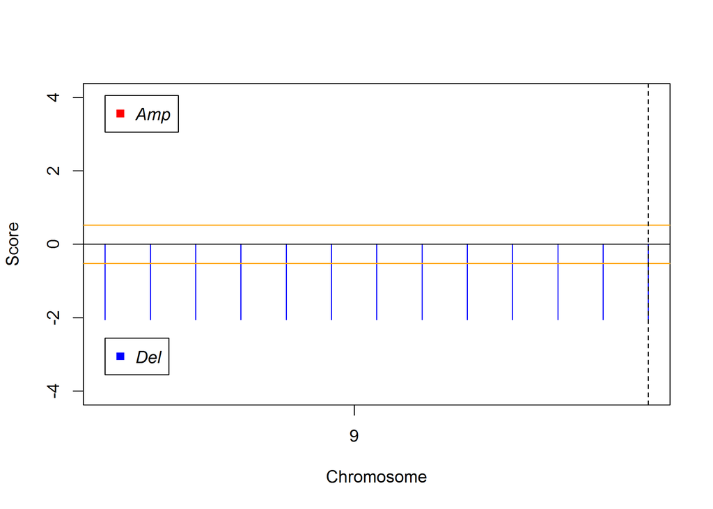

```r
gaiaCNVplot(RecCNV,threshold)
```

```r
save(results, RecCNV, threshold, file = paste0(cancer,"_CNV_results.rda"))
```

```r
library(maftools)

# Descargar archivos MAF (Mutation Annotation Format)
LGGmut <- GDCquery_Maf(tumor = "LGG", pipelines = "mutect2")
GBMmut <- GDCquery_Maf(tumor = "GBM", pipelines = "mutect2")

# Se fusionan
mut <- plyr::rbind.fill(LGGmut, GBMmut)
save(maf=mut,file ="mafMutect2LGGGBM.rda", compress = "xz")
```

```r
library(maftools)

# Se recuperan datos del paquete TCGAWorkflowData
data(mafMutect2LGGGBM)

# Se preparan maftools incluyendo datos clínicos
# Un mutante vs análisis de supervivencia WT
# Conseguir datos de pacientes clínicos identificados para muestras GBM
gbm_clin <- GDCquery_clinic(project = "TCGA-GBM", type = "Clinical")
# Conseguir datos de pacientes clínicos identificados para muestras LGG
lgg_clin <- GDCquery_clinic(project = "TCGA-LGG", type = "Clinical")

# Fusión de resultados
clinical <- plyr::rbind.fill(gbm_clin,lgg_clin)
colnames(clinical)[1] <- "Tumor_Sample_Barcode"
clinical$Overall_Survival_Status <- 1
clinical$Overall_Survival_Status[which(clinical$vital_status != "dead")] <- 0
clinical$time <- clinical$days_to_death
clinical$time[is.na(clinical$days_to_death)] <- clinical$days_to_last_follow_up[is.na(clinical$days_to_death)]

# Se genera objeto para usar en maftools
maf <- read.maf(maf = mut, clinicalData = clinical, isTCGA = T)
```

Se representa un resumen gráfico:

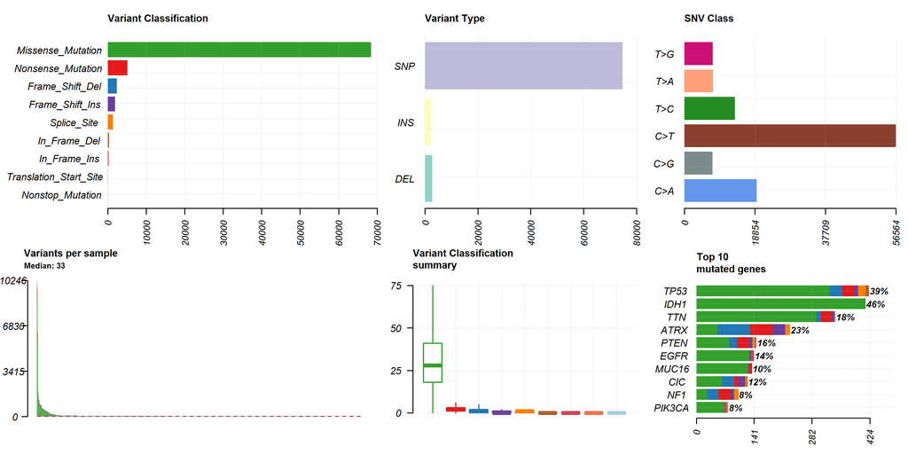

```r
plotmafSummary(maf = maf,
               rmOutlier = TRUE,
               addStat = 'median',
               dashboard = TRUE)
```

El objeto maf generado por read.maf se puede dibujar con la función *oncoplot()*.

```r
oncoplot(maf = maf,
         top = 20,
         legendFontSize = 8,
         clinicalFeatures = c("tissue_or_organ_of_origin"))
```

[output not shown]

Mediante la función *mafSurvival()* se puede mostrar la representación gráfica del análisis de supervivencia agrupando muestras de maf en función del estado de mutación de un gen o grupos dados o agrupando manualmente las muestras.

```
## IDH1
##  413
##     Group medianTime   N
## 1: Mutant        748 412
## 2:     WT        372 485
```

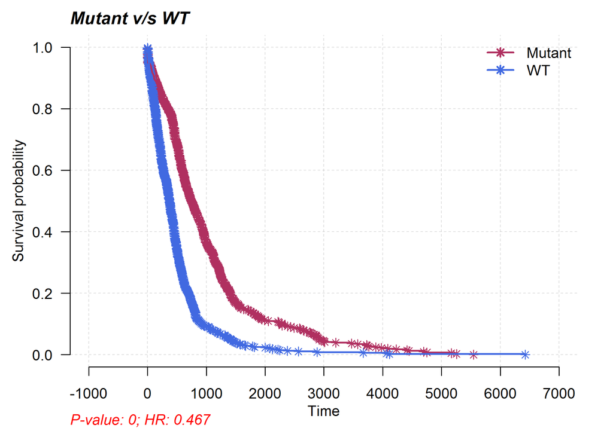

```r
plot <- mafSurvival(maf = maf,
                   genes = "IDH1",
                   fn = NULL,
                   time = 'time',
                   Status = 'Overall_Survival_Status',
                   isTCGA = TRUE)
```

```r
LGGmut <- GDCquery_Maf(tumor = "LGG", pipelines = "mutect2")
```

Las alteraciones genéticas en cromosomas determinados o todo el genoma (CNV, mutaciones) se pueden representar mediante *circos plot* gráficamente. Con el paquete GAIA se obtienen CNV significativos, que se muestran con las mutaciones recurrentes, resultado de variaciones genéticas tratadas recuperadas de TCGA, presentes en al menos dos muestras de tumores en LGG.

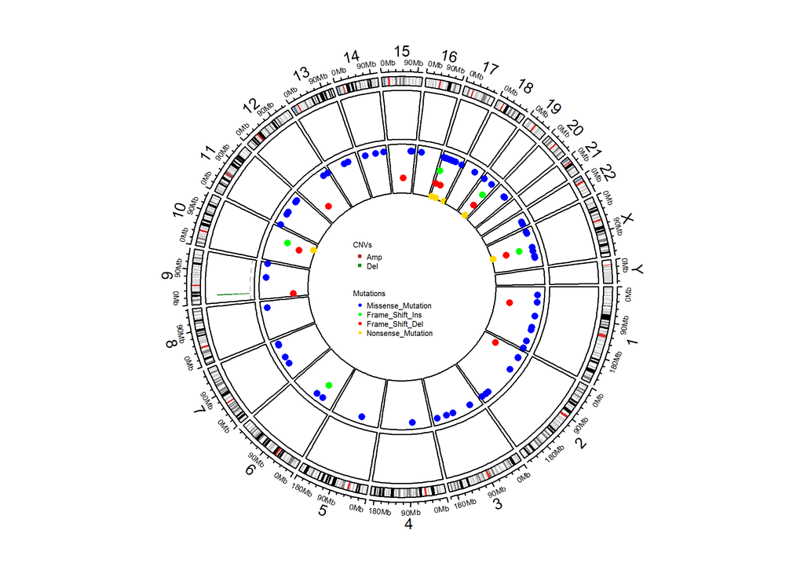

```r
# Resumen de aberración genómica (Circos plot)

# Recuperación de mutaciones tratadas para cáncer seleccionado
data(mafMutect2LGGGBM)

# Selección de mutaciones potencialmente dañinas
LGGmut <- LGGmut[LGGmut$Variant_Classification %in% c("Missense_Mutation",
                                                      "Nonsense_Mutation",
                                                      "Nonstop_Mutation",
                                                      "Frame_Shift_Del",
                                                      "Frame_Shift_Ins"),]

# Seleccionar mutaciones recurrentes en al menos dos muestras
mut.id <- paste0(LGGmut$Chromosome,":",LGGmut$Start_Position,"-",LGGmut$End_Position,"|",LGGmut$Reference_Allele)
mut <- cbind(mut.id, LGGmut)

# Preparar datos de mutaciones seleccionadas para circos plot
s.mut <- mut[mut$mut.id %in% unique(mut.id[duplicated(mut.id)]),]
s.mut <- s.mut[,c("Chromosome","Start_Position","End_Position","Variant_Classification","Hugo_Symbol")]
s.mut <- unique(s.mut)
typeNames <- unique(s.mut[,4])
type <- c(4:1)
names(type) <- typeNames[1:4]
Type <- type[s.mut[,4]]
s.mut <- cbind(s.mut,Type)
s.mut <- s.mut[,c(1:3,6,4,5)]

# Cargar datos CNV recurrentes para cáncer seleccionado
load("GBM_CNV_results.rda")

# Preparar datos CNV de muestra seleccionada para circos plot
s.cnv <- as.data.frame(RecCNV[RecCNV[,"q-value"] <= threshold,c(1:4,6)])
s.cnv <- s.cnv[,c(1,3,4,2)]
s.cnv[s.cnv$Chromosome == 23,"Chromosome"] <- "X"
s.cnv[s.cnv$Chromosome == 24,"Chromosome"] <- "Y"
Chromosome <- paste0("chr",s.cnv[,1])
s.cnv <- cbind(Chromosome, s.cnv[,-1])
s.cnv[,1] <- as.character(s.cnv[,1])
s.cnv[,4] <- as.character(s.cnv[,4])
s.cnv <- cbind(s.cnv,CNV=1)
colnames(s.cnv) <- c("Chromosome","Start_position","End_position","Aberration_Kind","CNV")

library(circlize)

# Dibujar circos plot genómicos
par(mar=c(1,1,1,1), cex=1)
circos.initializeWithIdeogram()

# Añadir resultados CNV
colors <- c("forestgreen","firebrick")
names(colors)  <- c(0,1)
circos.genomicTrackPlotRegion(s.cnv,  ylim = c(0,1.2),
                              panel.fun = function(region, value, ...) {
                                circos.genomicRect(region, value, ytop.column = 2, ybottom = 0,
                                                   col = colors[value[[1]]],
                                                   border="white")
                                cell.xlim = get.cell.meta.data("cell.xlim")
                                circos.lines(cell.xlim, c(0, 0), lty = 2, col = "#00000040")
                              })

# Añadir resultados de mutación
colors <- c("blue","green","red","gold")
names(colors)  <- typeNames[1:4]
circos.genomicTrackPlotRegion(s.mut, ylim = c(1.2,4.2),
                              panel.fun = function(region, value, ...) {
                                circos.genomicPoints(region, value, cex = 0.8, pch = 16, col = colors[value[[2]]], ...)
                              })

circos.clear()

legend(-0.2, 0.2, bty="n", y.intersp=1, c("Amp","Del"), pch=15,
       col=c("firebrick","forestgreen"), title="CNVs", text.font=1, cex=0.4, title.adj=0)
legend(-0.2, 0, bty="n", y.intersp=1, names(colors), pch=16,
       col=colors, title="Mutations", text.font=1, cex=0.4, title.adj=0)
```

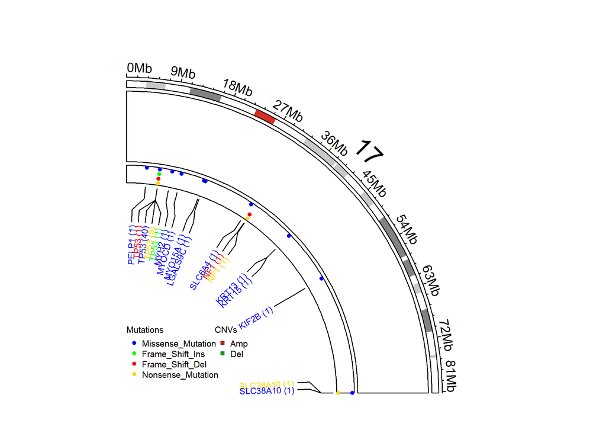

```r
par(mar=c(1,1,1,1),cex=1.5)
circos.par("start.degree" = 90, canvas.xlim = c(0, 1), canvas.ylim = c(0, 1),
           gap.degree = 270, cell.padding = c(0, 0, 0, 0), track.margin = c(0.005, 0.005))
circos.initializeWithIdeogram(chromosome.index = "chr17")
circos.par(cell.padding = c(0, 0, 0, 0))

# Añadir resultados CNV
colors <- c("forestgreen","firebrick")
names(colors)  <- c(0,1)
circos.genomicTrackPlotRegion(s.cnv,  ylim = c(0,1.2),
                              panel.fun = function(region, value, ...) {
                                circos.genomicRect(region, value, ytop.column = 2, ybottom = 0,
                                                   col = colors[value[[1]]],
                                                   border="white")
                                cell.xlim = get.cell.meta.data("cell.xlim")
                                circos.lines(cell.xlim, c(0, 0), lty = 2, col = "#00000040")
                              })

# Añadir resultados de mutación que representen genes individuales
genes.mut <- paste0(s.mut$Hugo_Symbol,"-",s.mut$Type)
s.mutt <- cbind(s.mut,genes.mut)
n.mut <- table(genes.mut)
idx <- !duplicated(s.mutt$genes.mut)
s.mutt <- s.mutt[idx,]
s.mutt <- cbind(s.mutt,num=n.mut[s.mutt$genes.mut])
genes.num <- paste0(s.mutt$Hugo_Symbol," (",s.mutt$num.Freq,")")
s.mutt <- cbind(s.mutt[,-c(6:8)],genes.num)
s.mutt[,6] <- as.character(s.mutt[,6])
s.mutt[,4] <- s.mutt[,4]/2
s.mutt$num.Freq <- NULL
colors <- c("blue","green","red","gold")
names(colors)  <- typeNames[1:4]
circos.genomicTrackPlotRegion(s.mutt, ylim = c(0.3,2.2), track.height = 0.05,
                              panel.fun = function(region, value, ...) {
                                circos.genomicPoints(region, value, cex = 0.4, pch = 16, col = colors[value[[2]]], ...)
                              })

circos.genomicTrackPlotRegion(s.mutt, ylim = c(0, 1), track.height = 0.1, bg.border = NA)
i_track = get.cell.meta.data("track.index")

circos.genomicTrackPlotRegion(s.mutt, ylim = c(0,1),
                              panel.fun = function(region, value, ...) {
                                circos.genomicText(region, value,
                                                   y = 1,
                                                   labels.column = 3,
                                                   col = colors[value[[2]]],
                                                   facing = "clockwise", adj = c(1, 0.5),
                                                   posTransform = posTransform.text, cex = 0.4, niceFacing = TRUE)
                              }, track.height = 0.1, bg.border = NA)

circos.genomicPosTransformLines(s.mutt,
                                posTransform = function(region, value)
                                  posTransform.text(region,
                                                    y = 1,
                                                    labels = value[[3]],
                                                    cex = 0.4, track.index = i_track+1),
                                direction = "inside", track.index = i_track)

circos.clear()

legend(0.25, 0.2, bty="n", y.intersp=1, c("Amp","Del"), pch=15,
       col=c("firebrick","forestgreen"), title="CNVs", text.font=1, cex=0.4, title.adj=0)
legend(0, 0.2, bty="n", y.intersp=1, names(colors), pch=16,
       col=colors, title="Mutations", text.font=1, cex=0.4, title.adj=0)
```

```r
query <- GDCquery(project = "TCGA-GBM",
                  data.category = "Gene expression",
                  data.type = "Gene expression quantification",
                  platform = "Illumina HiSeq",
                  file.type  = "results",
                  sample.type = c("Primary solid Tumor"),
                  legacy = TRUE)

# Se seleccionan 20 muestras
query$results[[1]] <-  query$results[[1]][1:20,]
GDCdownload(query)
gbm.exp <- GDCprepare(query,
                      save = TRUE,
                      summarizedExperiment = TRUE,
                      save.filename = "GBMIllumina_HiSeq.rda")

query <- GDCquery(project = "TCGA-LGG",
                  data.category = "Gene expression",
                  data.type = "Gene expression quantification",
                  platform = "Illumina HiSeq",
                  file.type  = "results",
                  sample.type = c("Primary solid Tumor"),
                  legacy = TRUE)

# Se seleccionan 20 muestras
query$results[[1]] <-  query$results[[1]][1:20,]
GDCdownload(query)
lgg.exp <- GDCprepare(query,
                      save = TRUE,
                      summarizedExperiment = TRUE,
                      save.filename = "LGGIllumina_HiSeq.rda")
```

```r
data("LGGIllumina_HiSeq")
data("GBMIllumina_HiSeq")

dataPrep_LGG <- TCGAanalyze_Preprocessing(object = lgg.exp,
                                          cor.cut = 0.6,
                                          datatype = "raw_count",
                                          filename = "LGG_IlluminaHiSeq_RNASeqV2.png")

dataPrep_GBM <- TCGAanalyze_Preprocessing(object = gbm.exp,
                                          cor.cut = 0.6,
                                          datatype = "raw_count",
                                          filename = "GBM_IlluminaHiSeq_RNASeqV2.png")

dataNorm <- TCGAanalyze_Normalization(tabDF = cbind(dataPrep_LGG, dataPrep_GBM),
                                      geneInfo = TCGAbiolinks::geneInfo,
                                      method = "gcContent") #18323   672

dataFilt <- TCGAanalyze_Filtering(tabDF = dataNorm,
                                  method = "quantile",
                                  qnt.cut =  0.25)  # 13742   672

save(dataFilt, file = paste0("LGG_GBM_Norm_IlluminaHiSeq.rda"))

dataFiltLGG <- subset(dataFilt, select = substr(colnames(dataFilt),1,12) %in% lgg_clin$bcr_patient_barcode)
dataFiltGBM <- subset(dataFilt, select = substr(colnames(dataFilt),1,12) %in% gbm_clin$bcr_patient_barcode)

dataDEGs <- TCGAanalyze_DEA(mat1 = dataFiltLGG,
                            mat2 = dataFiltGBM,
                            Cond1type = "LGG",
                            Cond2type = "GBM",
                            fdr.cut = 0.01 ,
                            logFC.cut = 1,
                            method = "glmLRT")
```

Se puede conocer el número de genes diferencialmente expresados:

```r
# Número de genes diferencialmente expresados (DEG)
nrow(dataDEGs)
```

[1] 2535

## Análisis de enriquecimiento

A continuación se representa gráficamente el análisis de enriquecimiento a partir de los datos obtenidos.

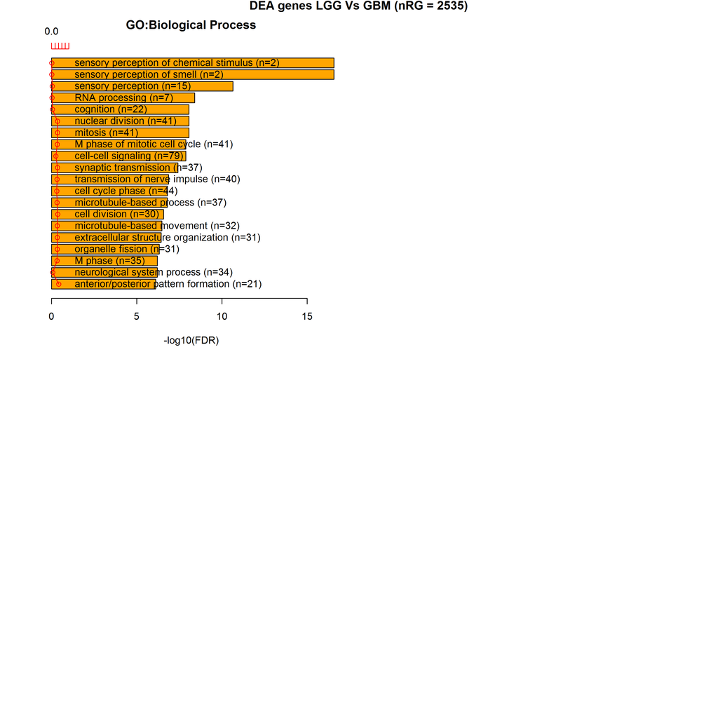

```r
# Análisis de enriquecimiento          --------------------
ansEA <- TCGAanalyze_EAcomplete(TFname="DEA genes LGG Vs GBM", RegulonList = rownames(dataDEGs))
TCGAvisualize_EAbarplot(tf = rownames(ansEA$ResBP),
                        filename = NULL,
                        GOBPTab = ansEA$ResBP,
                        nRGTab = rownames(dataDEGs),
                        nBar = 20)
```

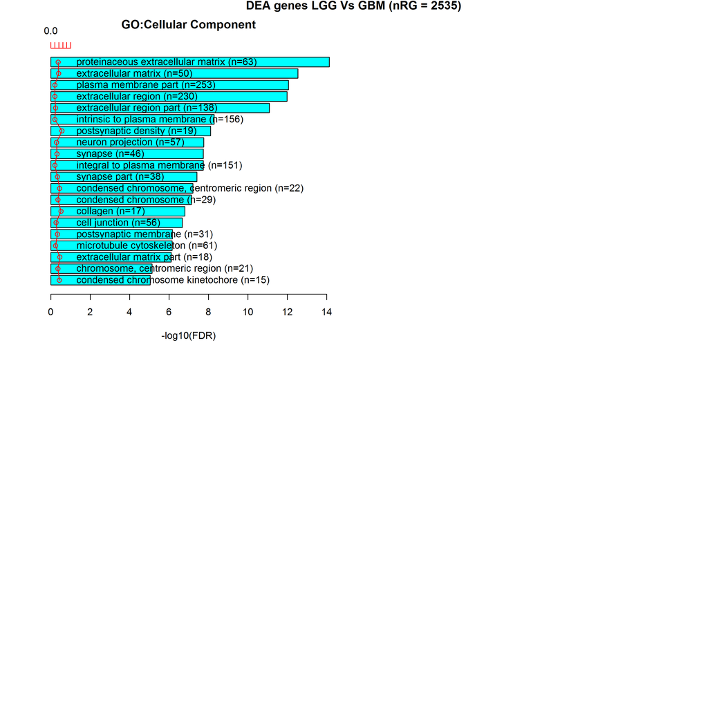

```r
TCGAvisualize_EAbarplot(tf = rownames(ansEA$ResBP),
                        filename = NULL,
                        GOCCTab = ansEA$ResCC,
                        nRGTab = rownames(dataDEGs),
                        nBar = 20)
```

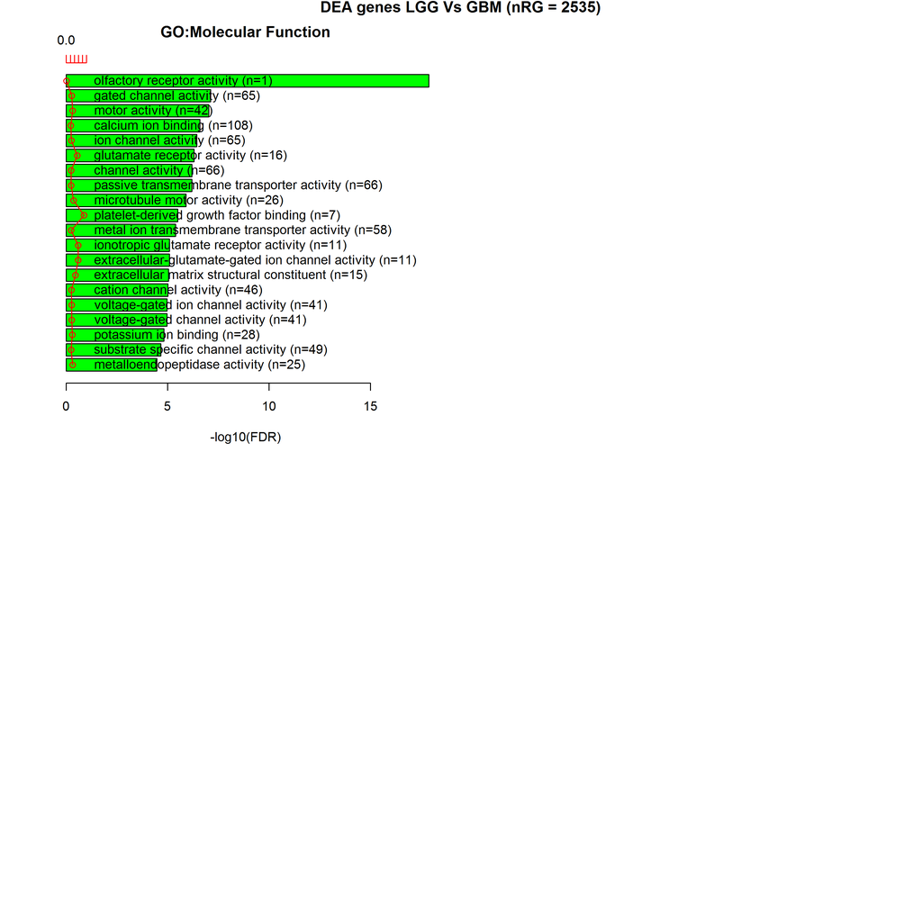

```r
TCGAvisualize_EAbarplot(tf = rownames(ansEA$ResBP),
                        filename = NULL,
                        GOMFTab = ansEA$ResMF,
                        nRGTab = rownames(dataDEGs),
                        nBar = 20)
```

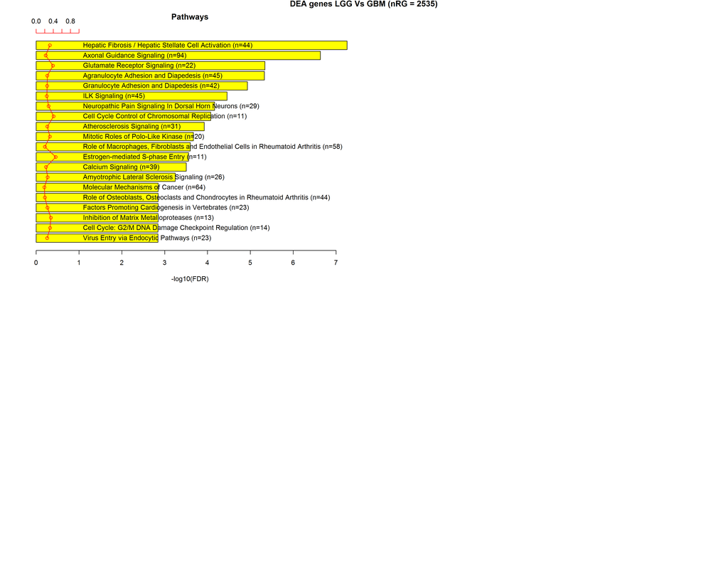

```r
TCGAvisualize_EAbarplot(tf = rownames(ansEA$ResBP),
                        filename = NULL,
                        PathTab = ansEA$ResPat,
                        nRGTab = rownames(dataDEGs),
                        nBar = 20)
```

```r
library(SummarizedExperiment)
GenelistComplete <- rownames(assay(lgg.exp,1))

# TopTable de DEG
dataDEGsFiltLevel <- TCGAanalyze_LevelTab(dataDEGs,"LGG","GBM",
                                          dataFilt[,colnames(dataFiltLGG)],
                                          dataFilt[,colnames(dataFiltGBM)])

dataDEGsFiltLevel$GeneID <- 0

library(clusterProfiler)

# Convertir "Gene symbol" a "geneID"
eg = as.data.frame(bitr(dataDEGsFiltLevel$mRNA,
                        fromType="SYMBOL",
                        toType="ENTREZID",
                        OrgDb="org.Hs.eg.db"))
eg <- eg[!duplicated(eg$SYMBOL),]

dataDEGsFiltLevel <- dataDEGsFiltLevel[dataDEGsFiltLevel$mRNA %in% eg$SYMBOL,]

dataDEGsFiltLevel <- dataDEGsFiltLevel[order(dataDEGsFiltLevel$mRNA,decreasing=FALSE),]
eg <- eg[order(eg$SYMBOL,decreasing=FALSE),]

# table(eg$SYMBOL == dataDEGsFiltLevel$mRNA) debería ser TRUE
all(eg$SYMBOL == dataDEGsFiltLevel$mRNA)
```

[1] TRUE

```r
dataDEGsFiltLevel$GeneID <- eg$ENTREZID

dataDEGsFiltLevel_sub <- subset(dataDEGsFiltLevel, select = c("GeneID", "logFC"))
genelistDEGs <- as.numeric(dataDEGsFiltLevel_sub$logFC)
names(genelistDEGs) <- dataDEGsFiltLevel_sub$GeneID
library(pathview)
# pathway.id: hsa05214 es el pathway del glioma
hsa05214 <- pathview::pathview(gene.data  = genelistDEGs,
                               pathway.id = "hsa05214",
                               species    = "hsa",
                               limit = list(gene=as.integer(max(abs(genelistDEGs)))))
```

```r
file <- "http://thebiogrid.org/downloads/archives/Release%20Archive/BIOGRID-3.4.146/BIOGRID-ALL-3.4.146.tab2.zip"
if(!file.exists(gsub("zip","txt",basename(file)))){
  downloader::download(file,basename(file))
  unzip(basename(file),junkpaths =TRUE)
  }

tmp.biogrid <- read.csv(gsub("zip","txt",basename(file)), header=TRUE, sep="\t", stringsAsFactors=FALSE)
```

```r
#  DNA metilación
#  Muestras
lgg.samples <- matchedMetExp("TCGA-LGG", n = 10)
gbm.samples <- matchedMetExp("TCGA-GBM", n = 10)
samples <- c(lgg.samples,gbm.samples)

query <- GDCquery(project = c("TCGA-LGG","TCGA-GBM"),
                  data.category = "DNA methylation",
                  platform = "Illumina Human Methylation 450",
                  legacy = TRUE,
                  barcode = samples)

GDCdownload(query)

met <- GDCprepare(query, save = FALSE)

# Se realiza para cromosoma 9
met <- subset(met,subset = as.character(seqnames(met)) %in% c("chr9"))
```

```
##     groups      Mean    Median       Max       Min
## 1 TCGA-GBM 0.4755915 0.4755397 0.5039685 0.4284987
## 2 TCGA-LGG 0.5271248 0.5283638 0.5661392 0.4441902
##             TCGA-GBM    TCGA-LGG
## TCGA-GBM          NA 0.001033341
## TCGA-LGG 0.001033341          NA
```

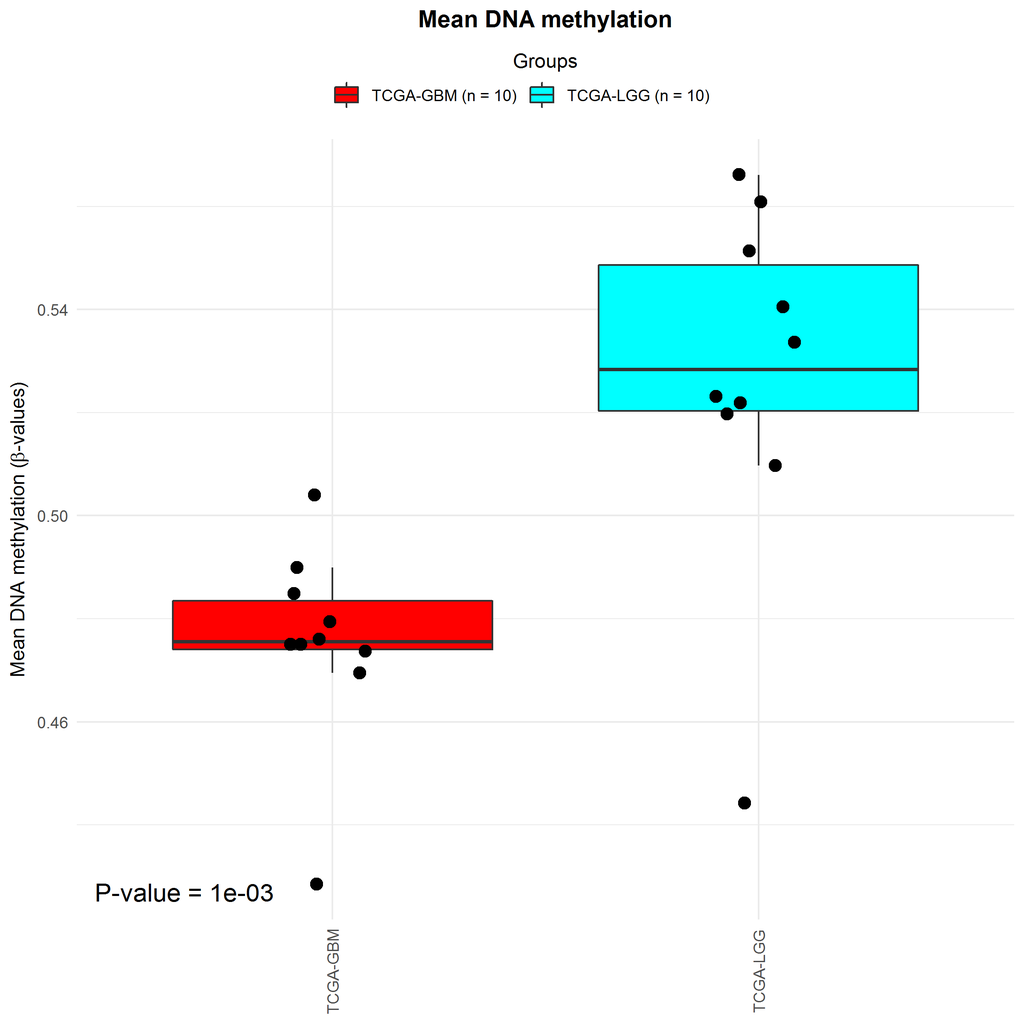

```r
data(elmerExample) # información disponible en paquete ELMER

# Metilación media

# Plot para grupos de la columna enfermedad del objeto summarizedExperiment

# Eliminar sondas NA
met <- subset(met,subset = (rowSums(is.na(assay(met))) == 0))

TCGAvisualize_meanMethylation(met,
                              groupCol = "project_id",
                              group.legend  = "Groups",
                              filename = NULL,
                              print.pvalue = TRUE)
```

```r
# Sitios CpG metilados diferencialmente
dmc <- TCGAanalyze_DMR(met,
                       groupCol = "project_id", # una columna en colData matrix
                       group1 = "TCGA-GBM", # un tipo de enfermedad (type column)
                       group2 = "TCGA-LGG", # un tipo de la columna enfermedad
                       p.cut = 0.05,
                       diffmean.cut = 0.15,
                       save = FALSE,
                       legend = "State",
                       plot.filename = "LGG_GBM_metvolcano.png",
                       cores = 1 # bar
)
```

```r
# Heatmap de metilación de DNA

library(ComplexHeatmap)
clinical <- plyr::rbind.fill(gbm_clin,lgg_clin)

# Conseguir sondas hipermetiladas o hipometiladas (objeto de análisis de metilación de DNA)
status.col <- "status"
probes <- rownames(dmc)[grep("hypo|hyper",dmc$status,ignore.case = TRUE)]
sig.met <- met[probes,]

# TOP Annotation (se añaden datos clínicos como anotación de muestras y se ordena)
clinical.order <- clinical[match(substr(colnames(sig.met),1,12),clinical$bcr_patient_barcode),]
ta = HeatmapAnnotation(df = clinical.order[, c("disease", "gender", "vital_status", "race")],
                       col = list(
                         disease = c("LGG" = "grey", "GBM" = "black"),
                         gender = c("male" = "blue", "female" = "pink")
                       ))

heatmap <- Heatmap(assay(sig.met),
                    name = "DNA methylation",
                    col = matlab::jet.colors(200),
                    show_row_names = FALSE,
                    cluster_rows = TRUE,
                    cluster_columns = FALSE,
                    show_column_names = FALSE,
                    bottom_annotation = ta,
                    column_title = "DNA Methylation")

# Se guarda como pdf
png("heatmap.png",width = 600, height = 400)
draw(heatmap, annotation_legend_side =  "bottom")
dev.off()
```

**R version 3.6.1 (2019-07-05)**

**Platform:** x86_64-w64-mingw32/x64 (64-bit)

**locale:** *LC_COLLATE=Spanish_Spain.1252*, *LC_CTYPE=Spanish_Spain.1252*, *LC_MONETARY=Spanish_Spain.1252*, *LC_NUMERIC=C* and *LC_TIME=Spanish_Spain.1252*

**attached base packages:**

- stats4
- grid
- parallel
- stats
- graphics
- grDevices
- utils
- datasets
- methods
- base

**other attached packages:**

- clusterProfiler(v.3.12.0)
- circlize(v.0.4.10)
- maftools(v.2.0.16)
- SummarizedExperiment(v.1.14.1)
- DelayedArray(v.0.10.0)
- BiocParallel(v.1.18.1)
- matrixStats(v.0.56.0)
- GenomicRanges(v.1.36.1)
- GenomeInfoDb(v.1.20.0)
- GenomicDataCommons(v.1.10.0)
- magrittr(v.1.5)
- RTCGAToolbox(v.2.14.0)
- minet(v.3.44.1)
- gaia(v.2.30.0)
- pathview(v.1.24.0)
- org.Hs.eg.db(v.3.8.2)
- AnnotationDbi(v.1.46.1)
- IRanges(v.2.18.3)
- S4Vectors(v.0.22.1)
- Biobase(v.2.44.0)
- ComplexHeatmap(v.2.0.0)
- AnnotationHub(v.2.16.1)
- BiocFileCache(v.1.8.0)
- dbplyr(v.1.4.4)
- BiocGenerics(v.0.32.0)
- TCGAbiolinks(v.2.14.0)
- DT(v.0.13)
- TCGAWorkflowData(v.1.8.0)

**loaded via a namespace (and not attached):**

- rappdirs(v.0.3.1)
- rtracklayer(v.1.44.4)
- ggthemes(v.4.2.0)
- R.methodsS3(v.1.8.0)
- pkgmaker(v.0.31.1)
- tidyr(v.1.1.0)
- ggplot2(v.3.3.2)
- bit64(v.0.9-7)
- knitr(v.1.28)
- aroma.light(v.3.14.0)
- R.utils(v.2.9.2)
- data.table(v.1.12.8)
- hwriter(v.1.3.2)
- KEGGREST(v.1.24.1)
- RCurl(v.1.98-1.2)
- doParallel(v.1.0.15)
- generics(v.0.0.2)
- GenomicFeatures(v.1.36.4)
- cowplot(v.1.0.0)
- RSQLite(v.2.2.0)
- europepmc(v.0.4)
- bit(v.1.1-15.2)
- enrichplot(v.1.4.0)
- xml2(v.1.3.2)
- httpuv(v.1.5.4)
- assertthat(v.0.2.1)
- viridis(v.0.5.1)
- xfun(v.0.14)
- hms(v.0.5.3)
- evaluate(v.0.14)
- promises(v.1.1.1)
- progress(v.1.2.2)
- readxl(v.1.3.1)
- Rgraphviz(v.2.28.0)
- km.ci(v.0.5-2)
- igraph(v.1.2.5)
- DBI(v.1.1.0)
- geneplotter(v.1.62.0)
- htmlwidgets(v.1.5.1)
- EDASeq(v.2.18.0)
- matlab(v.1.0.2)
- purrr(v.0.3.4)
- ellipsis(v.0.3.1)
- crosstalk(v.1.1.0.1)
- selectr(v.0.4-2)
- dplyr(v.1.0.0)
- ggpubr(v.0.3.0)
- backports(v.1.1.7)
- annotate(v.1.62.0)
- gridBase(v.0.4-7)
- biomaRt(v.2.40.5)
- vctrs(v.0.3.1)
- abind(v.1.4-5)
- withr(v.2.2.0)
- ggforce(v.0.3.1)
- triebeard(v.0.3.0)
- GenomicAlignments(v.1.20.1)
- prettyunits(v.1.1.1)
- cluster(v.2.1.0)
- DOSE(v.3.10.2)
- crayon(v.1.3.4)
- genefilter(v.1.66.0)
- labeling(v.0.3)
- edgeR(v.3.26.8)
- pkgconfig(v.2.0.3)
- tweenr(v.1.0.1)
- nlme(v.3.1-148)
- wordcloud(v.2.6)
- rlang(v.0.4.6)
- RJSONIO(v.1.3-1.4)
- lifecycle(v.0.2.0)
- downloader(v.0.4)
- registry(v.0.5-1)
- polyclip(v.1.10-0)
- cellranger(v.1.1.0)
- graph(v.1.62.0)
- rngtools(v.1.5)
- urltools(v.1.7.3)
- Matrix(v.1.2-18)
- KMsurv(v.0.1-5)
- carData(v.3.0-4)
- zoo(v.1.8-8)
- ggridges(v.0.5.2)
- GlobalOptions(v.0.1.2)
- viridisLite(v.0.3.0)
- png(v.0.1-7)
- rjson(v.0.2.20)
- bitops(v.1.0-6)
- R.oo(v.1.23.0)
- ConsensusClusterPlus(v.1.48.0)
- pander(v.0.6.3)
- Biostrings(v.2.52.0)
- blob(v.1.2.1)
- shape(v.1.4.4)
- stringr(v.1.4.0)
- qvalue(v.2.16.0)
- ShortRead(v.1.42.0)
- gridGraphics(v.0.5-0)
- readr(v.1.3.1)
- jpeg(v.0.1-8.1)
- rstatix(v.0.5.0)
- ggsignif(v.0.6.0)
- scales(v.1.1.1)
- memoise(v.1.1.0)
- plyr(v.1.8.6)
- bibtex(v.0.4.2.2)
- zlibbioc(v.1.30.0)
- compiler(v.3.6.1)
- RColorBrewer(v.1.1-2)
- clue(v.0.3-57)
- KEGGgraph(v.1.44.0)
- Rsamtools(v.2.0.3)
- XVector(v.0.24.0)
- MASS(v.7.3-51.6)
- mgcv(v.1.8-31)
- tidyselect(v.1.1.0)
- stringi(v.1.4.6)
- forcats(v.0.5.0)
- yaml(v.2.2.1)
- GOSemSim(v.2.10.0)
- locfit(v.1.5-9.4)
- latticeExtra(v.0.6-29)
- ggrepel(v.0.8.2)
- survMisc(v.0.5.5)
- fastmatch(v.1.1-0)
- tools(v.3.6.1)
- RaggedExperiment(v.1.10.0)
- rio(v.0.5.16)
- foreach(v.1.5.0)
- foreign(v.0.8-71)
- gridExtra(v.2.3)
- farver(v.2.0.3)
- ggraph(v.2.0.3)
- rvcheck(v.0.1.8)
- digest(v.0.6.25)
- BiocManager(v.1.30.10)
- shiny(v.1.4.0.2)
- Rcpp(v.1.0.4.6)
- car(v.3.0-8)
- broom(v.0.5.6)
- later(v.1.1.0.1)
- httr(v.1.4.1)
- survminer(v.0.4.7)
- RCircos(v.1.2.1)
- colorspace(v.1.4-1)
- rvest(v.0.3.5)
- XML(v.3.99-0.3)
- splines(v.3.6.1)
- graphlayouts(v.0.7.0)
- ggplotify(v.0.0.5)
- xtable(v.1.8-4)
- jsonlite(v.1.6.1)
- tidygraph(v.1.2.0)
- UpSetR(v.1.4.0)
- R6(v.2.4.1)
- pillar(v.1.4.4)
- htmltools(v.0.5.0)
- mime(v.0.9)
- NMF(v.0.22.0)
- glue(v.1.4.1)
- fastmap(v.1.0.1)
- DESeq(v.1.36.0)
- interactiveDisplayBase(v.1.22.0)
- codetools(v.0.2-16)
- fgsea(v.1.10.1)
- lattice(v.0.20-38)
- tibble(v.3.0.1)
- sva(v.3.32.1)
- curl(v.4.3)
- zip(v.2.0.4)
- GO.db(v.3.8.2)
- openxlsx(v.4.1.5)
- survival(v.3.2-3)
- limma(v.3.40.6)
- rmarkdown(v.2.2)
- munsell(v.0.5.0)
- DO.db(v.2.9)
- GetoptLong(v.1.0.0)
- GenomeInfoDbData(v.1.2.1)
- iterators(v.1.0.12)
- haven(v.2.3.1)
- reshape2(v.1.4.4)
- gtable(v.0.3.0)